# Region 5 State of the Child: Draft Data Findings and Visuals

Catalyst California

25 May, 2023

The following site holds the draft findings and draft visuals from various data sources to better understand the well-being and health of children in Best Start Region 5, the Antelope Valley. The findings and visuals are being developed by Catalyst California for the Region 5 State of the Child report in collaboration with The Children’s Bureau.

```r
# Prep and Set Up
#### Loading Libraries ####
library(dplyr)
library(ggplot2)
library(RPostgreSQL)
library(devtools)
library(janitor)
library(tidyr)
library(data.table)
library(sysfonts)
library(showtext)
library(sf)
library(stringr)
library(DT)
library(formattable)
library(knitr)
library(rgdal)
library(RColorBrewer)
library(scales)
library(colorspace)
library(devtools)
library(broom)
library(reshape2)
library(extrafont)
library(sp)
library(tigris)
library(forcats)
library(ggtext)
library(ggrepel)
library(rlang)
library(svglite)
library(kableExtra)
library(flextable)
library(highcharter)
#### First 5 LA Style Guide ####
## COLORS## Taken from W:\Project\RDA Team\Region 5 State of the Child\Documentation\F5LA_BrandGuidelines_COLORS.pdf
#primary
lightblue <- "#009CDB"
darkblue <- "#332985"
tealblue <- "#22BCB8"
black <- "#000000"
textgrey <- "#919191"
#secondary
green <- "#54B847"
orange <- "#F58326"
hotpink <- "#EC098C"
red <- "#EF4034"

## FONTS ##
# Step 1: Download fonts (Gotham Bold and Gotham Book)
# Step 2: Load the downloaded fonts into the R script:
# General: See tutorial here, under "THE SHOWTEXT PACKAGE" section: https://r-coder.com/custom-fonts-r/#The_showtext_package
# Step 3: Run the code below in each R script

font_add(family = "GothamBold", regular = "C:/Windows/Fonts/Gotham-Bold 700.otf")
font_add(family = "GothamBook", regular = "C:/Windows/Fonts/Gotham-Book 325.otf")

showtext_auto()

# define fonts in chart
font_title <- "GothamBold"
font_subtitle <- "GothamBook"
font_caption <- "GothamBook"
font_bar_label <- "GothamBold"
font_axis_label <- "GothamBook"
font_table_text<-"GothamBook"

#### Loading Database from PgAdmin/Postgres ####
source("W:\\RDA Team\\R\\credentials_source.R")

#con_rc

#### Static Visual Functions ####

#Reference: W:\Project\RDA Team\LAFed\R\LAFed\visual_functions_static.R
```

# Demographics

## Population of Children and Families

The Antelope Valley is a 2,200 square mile area in northern Los Angeles County [1](https://en.wikipedia.org/wiki/Antelope_Valley). According to the US Census, it’s two largest cities, Lancaster and Palmdale, have populations of 170,150 and 165,761, respectively.1. For comparison, both cities are more populous than Pasadena and Pomona, two well-known mid-size cities on the other side of the valley.

**The Antelope Valley Best Start Region 5 is home to a population of 368,522 people [1](https://public.tableau.com/app/profile/luz3725/viz/2020CensusData-AVBESTSTARTREGION5/GRAPI)**. According to Catalyst California calculations of 2020 American Community Survey estimates, **the Lancaster and Palmdale Best Start geographies hold roughly 25,000 children**, with 12,821 and 13,068 children ages 0 to 5, respectively. These 25,000+ children represent more than 7% of the Lancaster and Palmdale Best Start geography populations.

## Racial Ethnic Breakdown

According to the latest American Community Survey data calculated by Lucy Wilkerson, **Region 5 is majority Latinx and the regional share of the Black population is twice the LA County share and nearly three times the State share**. On the other hand, the region is home to relatively fewer Asian residents than the County and State as a whole.

**Race-ethnicity of Region 5 and Key Geographies**

```r
source("W:/Project/RDA Team/Region 5 State of the Child/R/race.R")

library(kableExtra)
kbl(race_data) %>%
  kable_styling(bootstrap_options = c("striped", "bordered", "condensed"))
```

| Geography | Latinx (%) | White (%) | Black (%) | AIAN (%) | Asian (%) | Pacific Islander (%) | Other (%) |
| --- | --- | --- | --- | --- | --- | --- | --- |
| LANCASTER | 42.7 | 28.7 | 20.5 | 0.3 | 4.3 | 0.1 | 3.8 |
| PALMDALE | 60.4 | 21.3 | 11.3 | 0.6 | 4.1 | 0.4 | 2.5 |
| EAST ANTELOPE VALLEY | 68.5 | 21.1 | 5.9 | 1.8 | 1.2 | 0.0 | 3.3 |
| WEST ANTELOPE VALLEY | 12.1 | 71.5 | 1.1 | 3.9 | 10.5 | 0.0 | 4.8 |
| LAKE LOS ANGELES | 59.4 | 32.9 | 5.1 | 0.0 | 0.3 | 0.0 | 2.3 |
| QUARTZ HILL | 32.4 | 49.6 | 8.9 | 1.5 | 3.5 | 0.2 | 5.4 |
| ANTELOPE VALLEY BEST START REGION 5 | 51.9 | 26.2 | 14.6 | 0.6 | 3.9 | 0.2 | 3.2 |
| LOS ANGELES COUNTY | 48.3 | 25.9 | 7.8 | 0.2 | 14.6 | 0.2 | 3.1 |
| CALIFORNIA | 39.1 | 36.5 | 5.4 | 0.3 | 14.6 | 0.4 | 3.7 |

Source: [American Community Survey 2016-2020 5-year estimates calculated for Antelope Valley neighborhoods by Lucy Wilkerson](https://public.tableau.com/app/profile/luz3725/viz/2020CensusData-AVBESTSTARTREGION5/GRAPI). Note: All racial-ethnic groups in the table other than Latinx are non-Hispanic. Lancaster and Palmdale above are neighborhoods created by census tract aggregations as opposed to cities.

## Black Infant Mortality

According to the California Department of Public Health, Los Angeles County 20015-17 Black infant mortality rates are more than twice the rate of infant mortality overall (9.3 vs. 4.2 infant deaths per 1,000 live births). Not available by race, but First 5 LA reports 2011-16 Children’s Data Network infant mortality rates for the total populations of the Lancaster and Palmdale Best Start geographies at 6.0 and 5.7 per 1,000, respectively.[1](https://www.first5la.org/wp-content/uploads/2020/09/First-5-LA-2020-Indicators-Report.pdf)

**The County’s Black infant mortality rate is twice the infant mortality rate overall: 9.3 Black LA County infant deaths per 1,000 live births compared to total rate of 4.2 per 1,000**[1](https://data.chhs.ca.gov/dataset/infant-mortality-deaths-per-1000-live-births-lghc-indicator-01/resource/ae78da8f-1661-45f6-b2d0-1014857d16e3)

Recent data are a challenge as this data, from the California Health and Human Services Open Data Portal is from 2015-2017. The [African American Infant and Maternal Mortality (AAIMM) Initiative](https://www.blackinfantsandfamilies.org/) is a coalition working to address the unacceptably high rates of Black infant and maternal deaths in the County. [A Pathway to Equity](http://publichealth.lacounty.gov/centerforhealthequity/PDF/AAIM-ActionPlan.pdf) is a framework for understanding the causes of infant mortality and the steps needed to address it.

## Children of Incarcerated

According to Catalyst California calculations of Vera Institute for Justice, County of Los Angeles Probation, and the Bureau of Justice Statistics, there are an estimated **90,000 children in Los Angeles County with a parent in State Prison, LA County Jail, or under LA County probation and 17,000 of these children are ages 0 to 5**. This means that roughly 1 in 20 LA County children have an incarcerated parent or parent under probation. Roughly 20,000 of these children are Black with 4,000 of them between the age 0 to 5.

Because the criminal justice system over criminalizes Black and Brown parents, children of incarcerated parents or parents under probation are more likely to be Latino or Black than their share of the total population. **Black children make up 22% of Los Angeles County children with an incarcerated parent or parent under probation but are only 7.5% of the total population**. By contrast, White children make up 11.6% of county children with an incarcerated parent or parent under probation but are 20.4% of the total population.

```r
Race <- c("Percent children of incarcerated or probation parent", "Percent of County children", "Difference")
Black <- c("22.0%", "7.5%", "14.5%")
Latino <- c("63.0%",    "55.7%",    "7.3%")
NHPI <- c("0.1%",   "0.2%", "-0.1%")
AIAN <- c("0.1%",   "0.2%", "-0.1%")
Other <- c("2.8%",  "3.3%", "-0.5%")
White <- c("11.6%", "20.4%",    "-8.8%")
Asian <- c("0.4%",  "12.7%",    "-12.3%")
Total <- c("100%",  "100%", "0%")

incarc_table <- rbind(Race, Black, Latino, NHPI, AIAN, Other, White, Asian, Total)

library(kableExtra)
kbl(incarc_table) %>%
  kable_styling(bootstrap_options = c("striped", "bordered", "condensed"))
```

| Race | Percent children of incarcerated or probation parent | Percent of County children | Difference |
| --- | --- | --- | --- |
| Black | 22.0% | 7.5% | 14.5% |
| Latino | 63.0% | 55.7% | 7.3% |
| NHPI | 0.1% | 0.2% | -0.1% |
| AIAN | 0.1% | 0.2% | -0.1% |
| Other | 2.8% | 3.3% | -0.5% |
| White | 11.6% | 20.4% | -8.8% |
| Asian | 0.4% | 12.7% | -12.3% |
| Total | 100% | 100% | 0% |

Source: Catalyst California calculations of [2022 jail](https://www.vera.org/care-first-la-tracking-jail-decarceration) and [2020 prison](https://www.vera.org/downloads/publications/people-in-jail-and-prison-in-2020.pdf) population data from the Vera Institute of Justice and 2020 probation data from County of Los Angeles Probation.

This matters because separation or probation impacts the ability of parents to live with, supervise, and be attentive to their children. They are not as able to help with homework, know who their kids’ friends are, have a sense of how school is going, and what their children are eating, for example. Each of these things impact a child’s ability to succeed in school, be healthy, and otherwise thrive.

## Foster Youth Population

**Foster Youth Rates out of 100 by District 2021-22 School Year**

```r
source("W:/Project/RDA Team/Region 5 State of the Child/R/foster.R")
library(kableExtra)
av_table <- av_table %>% mutate(across(c(`2021-22 Count`), comma))

kbl(av_table) %>%
  kable_styling(bootstrap_options = c("striped", "bordered", "condensed"))
```

| Geography | 2021-22 Count | Rate (%) |
| --- | --- | --- |
| Antelope Valley Best Start Region 5 | 2,001 | 2.3 |
| Acton-Agua Dulce Unified School District | 108 | 0.9 |
| Antelope Valley Union Joint High School District | 488 | 2.1 |
| Eastside Union Elementary School District | 137 | 4.4 |
| Keppel Union Elementary School District | 36 | 1.3 |
| Lancaster Elementary School District | 518 | 3.5 |
| Palmdale Elementary School District | 520 | 2.5 |
| Westside Union Elementary School District | 171 | 1.9 |
| Wilsona Elementary School District | 23 | 1.9 |

Source: [California Department of Education, 2016-2022](https://dq.cde.ca.gov/dataquest/)

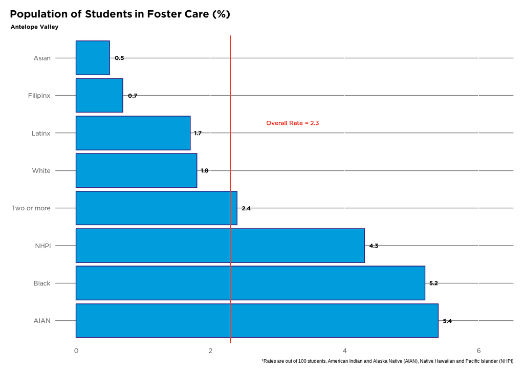

```r
# AV Bar Chart
s <- AV
tot = subset(s, select=c(total_rate)) %>% round(1)  # pull out total_rate
s = subset(s, select=-c(total_rate)) # pull out raced rates
oldnames = c("nh_black_rate","nh_aian_rate", "nh_asian_rate", "nh_filipino_rate", "latino_rate", "nh_pacisl_rate", "nh_white_rate", "nh_twoormor_rate")
engvar = c("Black", "AIAN", "Asian", "Filipinx", "Latinx", "NHPI", "White", "Two or more")
s = s %>% rename_at(vars(oldnames), ~ engvar)

# create english / spanish labels
engvar = c("Black", "AIAN", "Asian", "Filipinx", "Latinx", "NHPI", "White", "Two or more")
esvar = c("Negro", "Indígena Americano", "Asiático", "Filipino", "Latino", "Isleño del Pacifico", "Blanco", "Dos o mas")
#esvar_long = c("NEGRO O AFROAMERICANO", "INDÍGENA AMERICANO O NATIVO DE ALASKA", "ASIÁTICO", "FILIPINO", "LATINO", "ISLEÑO DEL PACIFICO", "BLANCO", "DOS O MAS")
labels <- data.frame(engvar, esvar)
# labels


# convert df to long format
s_long <- reshape2::melt(s, id.vars=c("geoname"))
# Round 'value' field to 1 decimal, rename 'variable' field, add Spanish labels
s_long <- s_long %>% mutate(value = round(value, 1)) %>% dplyr::rename(engvar = variable)  %>%
  left_join(labels, by = "engvar")
s_long <- s_long %>% filter(value > 0)


df <- data.frame(s_long, tot)       # add total_rate to long table
df <- na.omit(df)             # drop NA's
# df

engtot_stat <- paste("Overall Rate =", min(df$total_rate))   # total_rate line annotation
estot_stat <- paste("Promedio Total =", min(df$total_rate))   # total_rate line annotation


# Set region name for file name
region <- "Antelope Valley"


# write the name of your indicator here:
var <- "foster"


# Define chart height as max y value varies by indicator. Set vertical position for total line label - may need to be customized for each chart.
max_y = 1.15 * max(df$value)
annotate_y = 1.12 * df$total_rate

# specify language: comment out based on language of chart created below
lang <- "eng"

# # ggplot method that should export as .svg ##
av_plot <-
  #English
  ggplot(df, aes(x= reorder(engvar, -value), y=value)) +     # set up manual fill using 'test', add "-" before value to order bars when MAX is best
  annotate("text", x=6.25, y = annotate_y, label = str_wrap(engtot_stat, width = 20), hjust=-0.33, vjust = 0.35, family= font_table_text, color = red) +
  labs(title = "**<span style='font-size:20pt;'>Population of Students in Foster Care (%)</span>**", subtitle = region, caption = "*Rates are out of 100 students, American Indian and Alaska Native (AIAN), Native Hawaiian and Pacific Islander (NHPI)") +
  # rest of chart
  geom_bar(stat="identity", position = position_dodge(0.7), show.legend = FALSE) +
  geom_col(fill = lightblue, color = darkblue) +         # all bars in "#355C7D"
  geom_hline(aes(yintercept = round(total_rate, 1)), color = red, size = .5) +
  geom_text(aes(label = round(value, digits = 1)), family = font_bar_label, hjust = -.5) +       # format data labels, adjust hjust to avoid overlap w/ total line
  # scale_y_continuous(limits = c(0, max_y), breaks = seq(0, max_y, by = 20)) +
  scale_x_discrete(labels = function(engvar) str_wrap(engvar, width = 20)) +            # wrap long labels
  xlab("") +
  ylab("") +
  coord_flip()
# av_plot

av_plot <- av_plot + theme(
  panel.background = element_rect(fill = "transparent"), # bg of the panel
  plot.background = element_rect(fill = 'transparent', color=NA),
  panel.grid.major.y = element_line(colour = textgrey),    # add major y-axis gridlines
  panel.grid.minor = element_blank(), # bg of the plot
  axis.title.x = element_blank(),
  axis.title.y = element_blank(),
  axis.text.x = element_text(size = 12, family= font_axis_label),
  axis.text.y = element_text(size = 12, family= font_axis_label),
  axis.ticks = element_blank(),
  plot.title = element_markdown(family = font_title, face = "bold", size = 15, hjust = 0),
  plot.title.position = "plot",
  plot.subtitle = element_text(family = font_title, hjust = 0),
  plot.margin = margin(t = 10,
                       b = 10,
                       r = 10,
                       l = 10)
)


av_plot <- av_plot + ylim(0, max_y)     # add buffer between title and chart/data labels
av_plot
```

Source: [California Department of Education, 2016-2022](https://dq.cde.ca.gov/dataquest/)

## Student Migrant Population

Overall, 281 students (0.3% or 0.3 out of 100 students) are in the California’s Migrant Education Program in the Antelope Valley. This count is likely an undercount since this number represents only the students who are registered through the Migrant Education Program. Palmdale Elementary School District has a 2.7 times greater percentage of migratory students than the AV average.

**Student Migrant Population Counts by District 2021-22 School Year**

```r
source("W:/Project/RDA Team/Region 5 State of the Child/R/migrant.R")
library(kableExtra)

av_table <- av_table %>% mutate(across(c(`2021-22 Count`), comma))
kbl(av_table) %>%
  kable_styling(bootstrap_options = c("striped", "bordered", "condensed"))
```

| Geography | 2021-22 Count | Rate (%) |
| --- | --- | --- |
| Antelope Valley Best Start Region 5 | 281 | 0.3 |
| Acton-Agua Dulce Unified School District | 1 | 0.0 |
| Antelope Valley Union Joint High School District | 78 | 0.3 |
| Eastside Union Elementary School District | 5 | 0.2 |
| Lancaster Elementary School District | 14 | 0.1 |
| Palmdale Elementary School District | 177 | 0.8 |
| Westside Union Elementary School District | 2 | 0.0 |
| Wilsona Elementary School District | 4 | 0.3 |

Source: [California Department of Education, 2016-2022](https://dq.cde.ca.gov/dataquest/)

### Non-binary

The CDE started tracking students who identify as non-binary gender in the 2020-21 School Year. At that time, 23 students in the Antelope Valley identified as non-binary. Now in the 2021-22 School Year, that number has increased to 51 students (0.1% or 0.1 students out of 100) of the total AV student population. By percent, AIAN students had the highest rate of students who identified (0.6%) while in raw count Latinx students had the most students (26 students).

Non-binary gender is tracked via students or school staff such as teachers electing to change the student’s gender categorization on their Statewide Student Identifier (SSID). Because of the need for students to change their gender on their SSIDs to be counted as non-binary, this indicator likely undercounts non-binary students.

**Non-Binary Counts by School District 2021-22 School Year**

```r
source("W:/Project/RDA Team/Region 5 State of the Child/R/non-binary.R")
library(kableExtra)


kbl(av_table) %>%
  kable_styling(bootstrap_options = c("striped", "bordered", "condensed"))
```

| School Year | Count | Rate (%) |
| --- | --- | --- |
| 2021-22 | 51 | 0.1 |
| 2020-21 | 23 | 0.0 |

Source: [California Department of Education, 2016-2022](https://dq.cde.ca.gov/dataquest/)

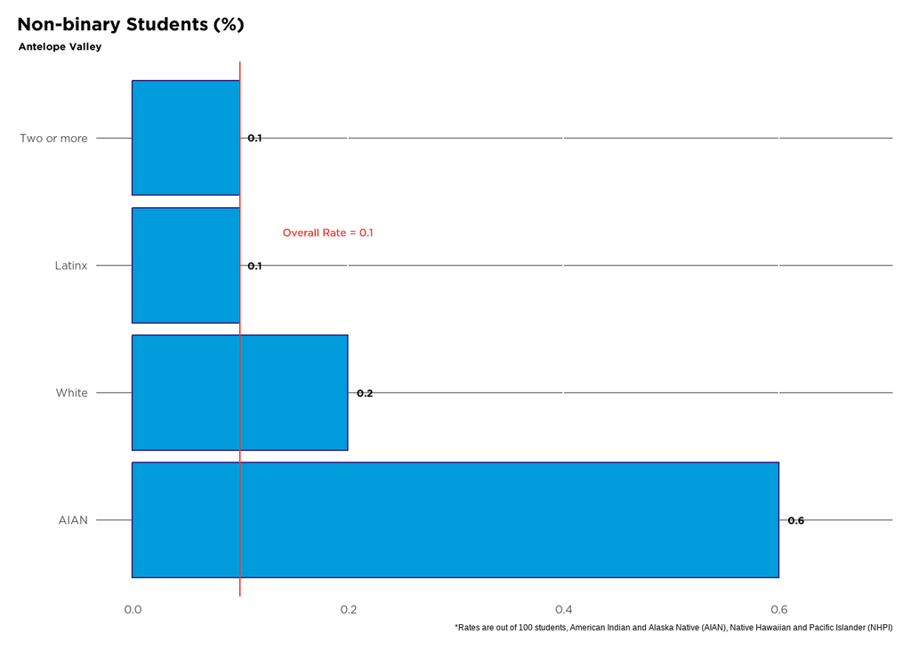

```r
# AV Bar Chart
s <- AV
tot = subset(s, select=c(total_rate)) %>% round(1)  # pull out total_rate
s = subset(s, select=-c(total_rate)) # pull out raced rates
oldnames = c("nh_black_rate","nh_aian_rate", "nh_asian_rate", "nh_filipino_rate", "latino_rate", "nh_pacisl_rate", "nh_white_rate", "nh_twoormor_rate")
engvar = c("Black", "AIAN", "Asian", "Filipinx", "Latinx", "NHPI", "White", "Two or more")
s = s %>% rename_at(vars(oldnames), ~ engvar)

# create english / spanish labels
engvar = c("Black", "AIAN", "Asian", "Filipinx", "Latinx", "NHPI", "White", "Two or more")
esvar = c("Negro", "Indígena Americano", "Asiático", "Filipino", "Latino", "Isleño del Pacifico", "Blanco", "Dos o mas")
#esvar_long = c("NEGRO O AFROAMERICANO", "INDÍGENA AMERICANO O NATIVO DE ALASKA", "ASIÁTICO", "FILIPINO", "LATINO", "ISLEÑO DEL PACIFICO", "BLANCO", "DOS O MAS")
labels <- data.frame(engvar, esvar)
# labels


# convert df to long format
s_long <- reshape2::melt(s, id.vars=c("geoname"))
# Round 'value' field to 1 decimal, rename 'variable' field, add Spanish labels
s_long <- s_long %>% mutate(value = round(value, 1)) %>% dplyr::rename(engvar = variable)  %>%
  left_join(labels, by = "engvar")
s_long <- s_long %>% filter(value > 0)


df <- data.frame(s_long, tot)       # add total_rate to long table
df <- na.omit(df)             # drop NA's
# df

engtot_stat <- paste("Overall Rate =", min(df$total_rate))   # total_rate line annotation
estot_stat <- paste("Promedio Total =", min(df$total_rate))   # total_rate line annotation


# Set region name for file name
region <- "Antelope Valley"


# write the name of your indicator here:
var <- "non-binary"


# Define chart height as max y value varies by indicator. Set vertical position for total line label - may need to be customized for each chart.
max_y = 1.12 * max(df$value)
annotate_y = 1.12 * df$total_rate

# specify language: comment out based on language of chart created below
lang <- "eng"

# # ggplot method that should export as .svg ##
av_plot <-
  #English
  ggplot(df, aes(x= reorder(engvar, -value), y=value)) +     # set up manual fill using 'test', add "-" before value to order bars when MAX is best
  annotate("text", x=3.25, y = annotate_y, label = str_wrap(engtot_stat, width = 20), hjust=-0.33, vjust = 0.35, family= font_table_text, color = red) +
  labs(title = "**<span style='font-size:20pt;'>Non-binary Students (%)</span>**", subtitle = region, caption = "*Rates are out of 100 students, American Indian and Alaska Native (AIAN), Native Hawaiian and Pacific Islander (NHPI)") +
  # rest of chart
  geom_bar(stat="identity", position = position_dodge(0.7), show.legend = FALSE) +
  geom_col(fill = lightblue, color = darkblue) +         # all bars in "#355C7D"
  geom_hline(aes(yintercept = round(total_rate, 1)), color = red, size = .5) +
  geom_text(aes(label = round(value, digits = 1)), family = font_bar_label, hjust = -.5) +       # format data labels, adjust hjust to avoid overlap w/ total line
  # scale_y_continuous(limits = c(0, max_y), breaks = seq(0, max_y, by = 20)) +
  scale_x_discrete(labels = function(engvar) str_wrap(engvar, width = 20)) +            # wrap long labels
  xlab("") +
  ylab("") +
  coord_flip()

av_plot <- av_plot + theme(
  panel.background = element_rect(fill = "transparent"), # bg of the panel
  plot.background = element_rect(fill = 'transparent', color=NA),
  panel.grid.major.y = element_line(colour = textgrey),    # add major y-axis gridlines
  panel.grid.minor = element_blank(), # bg of the plot
  axis.title.x = element_blank(),
  axis.title.y = element_blank(),
  axis.text.x = element_text(size = 12, family= font_axis_label),
  axis.text.y = element_text(size = 12, family= font_axis_label),
  axis.ticks = element_blank(),
  plot.title = element_markdown(family = font_title, face = "bold", size = 15, hjust = 0),
  plot.title.position = "plot",
  plot.subtitle = element_text(family = font_title, hjust = 0),
  plot.margin = margin(t = 10,
                       b = 10,
                       r = 10,
                       l = 10)
)


av_plot <- av_plot + ylim(0, max_y)     # add buffer between title and chart/data labels
av_plot
```

Source: [California Department of Education, 2016-2022](https://dq.cde.ca.gov/dataquest/)

## Socioeconomically Disadvantaged

The CDE has a category called Socioeconomically disadvantaged that it defines with the following criteria: * student is eligible or participating in the Free or Reduce Meal program, Migrant program, or Foster program * the student’s parents do not have a high school diploma * the student was Homeless, Directly Certified, a Tribal Foster Youth, or enrolled in a Juvenile Court School

In further definition, Direct Certification, means that the student was eligible for the Free Meal program without having to apply for it separately. That is usually because the student is already registered for other social or welfare services such as CalFresh or CalWORKs.(cde.ca.gov)

In the 2021-22 school year, an extremely high percentage, 75% of students (or 3 in every 4 students), were categorized as socioeconomically disadvantaged. In particular Black (84%), American Indian Alaskan Native (82%), and Latinx (80%) students had the highest rates in the Antelope Valley. In the the racial and ethnic groups with the lowest rates in the AV, still around half of students were considered socioeconomically disadvantaged. These high rates were specially pervasive in the Wilsona Elementary School District where 97%, almost all students where considered socioeconomically disadvantaged. In that district, Black and Native Hawaiian Pacific Islander students had the highest rates (approx. 100% for both), closely followed by Latinx students (98%).

**Socioeconomically Disadvantaged Counts and Rates out of 100 in the Antelope Valley 2021-22 School Year by School District**

```r
source("W:/Project/RDA Team/Region 5 State of the Child/R/socioeconomically_disadvantaged.R")
library(kableExtra)
# av_table <- av_table %>% filter(Geography=='Antelope Valley Best Start Region 5')
av_table <- av_table %>% mutate(across(c(`2021-22 Count`), comma))
kbl(av_table) %>%
 kable_styling(bootstrap_options = c("striped", "bordered", "condensed"))
```

| Geography | 2021-22 Count | Rate (%) |
| --- | --- | --- |
| Antelope Valley Best Start Region 5 | 65,395 | 75.2 |
| Acton-Agua Dulce Unified School District | 7,128 | 59.8 |
| Antelope Valley Union Joint High School District | 15,170 | 65.8 |
| Eastside Union Elementary School District | 2,758 | 88.3 |
| Hughes-Elizabeth Lakes Union Elementary School District | 76 | 46.9 |
| Keppel Union Elementary School District | 2,235 | 78.9 |
| Lancaster Elementary School District | 13,118 | 88.5 |
| Palmdale Elementary School District | 18,725 | 89.3 |
| Westside Union Elementary School District | 4,991 | 56.0 |
| Wilsona Elementary School District | 1,194 | 97.2 |

Source: [California Department of Education, 2016-2022](https://dq.cde.ca.gov/dataquest/)

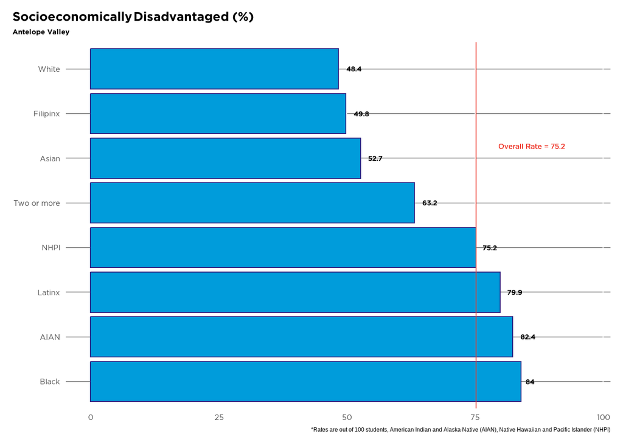

```r
## AV Bar Chart
s <- AV
tot = subset(s, select=c(total_rate)) %>% round(1)  # pull out total_rate
s = subset(s, select=-c(total_rate)) # pull out raced rates
oldnames = c("nh_black_rate","nh_aian_rate", "nh_asian_rate", "nh_filipino_rate", "latino_rate", "nh_pacisl_rate", "nh_white_rate", "nh_twoormor_rate")
engvar = c("Black", "AIAN", "Asian", "Filipinx", "Latinx", "NHPI", "White", "Two or more")
s = s %>% rename_at(vars(oldnames), ~ engvar)

# create english / spanish labels
engvar = c("Black", "AIAN", "Asian", "Filipinx", "Latinx", "NHPI", "White", "Two or more")
esvar = c("Negro", "Indígena Americano", "Asiático", "Filipino", "Latino", "Isleño del Pacifico", "Blanco", "Dos o mas")
#esvar_long = c("NEGRO O AFROAMERICANO", "INDÍGENA AMERICANO O NATIVO DE ALASKA", "ASIÁTICO", "FILIPINO", "LATINO", "ISLEÑO DEL PACIFICO", "BLANCO", "DOS O MAS")
labels <- data.frame(engvar, esvar)
# labels


# convert df to long format
s_long <- reshape2::melt(s, id.vars=c("geoname"))
# Round 'value' field to 1 decimal, rename 'variable' field, add Spanish labels
s_long <- s_long %>% mutate(value = round(value, 1)) %>% dplyr::rename(engvar = variable)  %>%
  left_join(labels, by = "engvar")
s_long <- s_long %>% filter(value > 0)


df <- data.frame(s_long, tot)       # add total_rate to long table
df <- na.omit(df)             # drop NA's
# df

engtot_stat <- paste("Overall Rate =", min(df$total_rate))   # total_rate line annotation
estot_stat <- paste("Promedio Total =", min(df$total_rate))   # total_rate line annotation


# Set region name for file name
region <- "Antelope Valley"


# write the name of your indicator here:
var <- "socioeconomically_disadvantaged"


# Define chart height as max y value varies by indicator. Set vertical position for total line label - may need to be customized for each chart.
max_y = 1.15 * max(df$value)
annotate_y = df$total_rate

# specify language: comment out based on language of chart created below
lang <- "eng"


# # ggplot method that should export as .svg ##
av_plot <-
  #English
  ggplot(df, aes(x= reorder(engvar, -value), y=value)) +     # set up manual fill using 'test', add "-" before value to order bars when MAX is best
  annotate("text", x=6.25, y = annotate_y, label = str_wrap(engtot_stat, width = 20), hjust=-0.33, vjust = 0.35, family= font_table_text, color = red) +
  labs(title = "**<span style='font-size:20pt;'>Socioeconomically Disadvantaged (%)</span>**", subtitle = region, caption = "*Rates are out of 100 students, American Indian and Alaska Native (AIAN), Native Hawaiian and Pacific Islander (NHPI)") +
  # rest of chart
  geom_bar(stat="identity", position = position_dodge(0.7), show.legend = FALSE) +
  geom_col(fill = lightblue, color = darkblue) +         # all bars in "#355C7D"
  geom_hline(aes(yintercept = round(total_rate, 1)), color = red, size = .5) +
  geom_text(aes(label = round(value, digits = 1)), family = font_bar_label, hjust = -.5) +       # format data labels, adjust hjust to avoid overlap w/ total line
  # scale_y_continuous(limits = c(0, max_y), breaks = seq(0, max_y, by = 20)) +
  scale_x_discrete(labels = function(engvar) str_wrap(engvar, width = 20)) +            # wrap long labels
  xlab("") +
  ylab("") +
  coord_flip()
# av_plot

av_plot <- av_plot + theme(
  panel.background = element_rect(fill = "transparent"), # bg of the panel
  plot.background = element_rect(fill = 'transparent', color=NA),
  panel.grid.major.y = element_line(colour = textgrey),    # add major y-axis gridlines
  panel.grid.minor = element_blank(), # bg of the plot
  axis.title.x = element_blank(),
  axis.title.y = element_blank(),
  axis.text.x = element_text(size = 12, family= font_axis_label),
  axis.text.y = element_text(size = 12, family= font_axis_label),
  axis.ticks = element_blank(),
  plot.title = element_markdown(family = font_title, face = "bold", size = 15, hjust = 0),
  plot.title.position = "plot",
  plot.subtitle = element_text(family = font_title, hjust = 0),
  plot.margin = margin(t = 10,
                       b = 10,
                       r = 10,
                       l = 10)
)


av_plot <- av_plot + ylim(0, max_y)     # add buffer between title and chart/data labels
av_plot
```

Source: [California Department of Education, 2016-2022](https://dq.cde.ca.gov/dataquest/)

## Student Homelessness

According to the California Department Of Education 2021_22 school year data, Student Homelessness on average in the Antelope Valley, 2.2% (or 2.2 out of 100), is slightly lower than the the state average, 2.9%, and Los Angeles County average, 2.8%. However, school district level data tells a different story.

The Hughes-Elizabeth Lakes Union Elementary School District and the Wilsona Elementary School District had the next highest rates, both being 2.3 times higher than the state average. For the Hughes-Elizabeth Lakes Union Elementary School District, the high rates for Latinx students were the highest (5.7%). In the case of the Wilsona Elementary School District, the high rates for Black (11.5%), Latinx (6.6%), and White students (6.2%) especially drove up the average.

The Eastside Union Elementary School District and Lancaster Elementary School District also had above average rates, being 2 and 1.2 times higher than the state average respectively. Regionally, students who identified as Non-Hispanic Two or More Races and Non-Hispanic Black and Non-Hispanic AIAN students had the highest rates.

Given this information, interventions targeting current elementary and middle school students, and Black, Latinx, AIAN, and Two or More Race students are pressing.

**Student Homelessness Rates out of 100 by School District 2021-22 School Year**

```r
# 2021-22 School Year Totals
source("W:/Project/RDA Team/Region 5 State of the Child/R/student_homelessness.R")
library(kableExtra)

 av_table <- av_table %>% mutate(across(c(`2021-22 Count`), comma))
kbl(av_table) %>%
  kable_styling(bootstrap_options = c("striped", "bordered", "condensed"))
```

| Geography | 2021-22 Count | Rate (%) |
| --- | --- | --- |
| Antelope Valley Best Start Region 5 | 1,936 | 2.2 |
| Acton-Agua Dulce Unified School District | 321 | 2.7 |
| Antelope Valley Union Joint High School District | 123 | 0.5 |
| Eastside Union Elementary School District | 161 | 5.2 |
| Hughes-Elizabeth Lakes Union Elementary School District | 11 | 6.8 |
| Keppel Union Elementary School District | 14 | 0.5 |
| Lancaster Elementary School District | 534 | 3.6 |
| Palmdale Elementary School District | 49 | 0.2 |
| Westside Union Elementary School District | 640 | 7.2 |
| Wilsona Elementary School District | 83 | 6.8 |

Source: [California Department of Education, 2016-2022](https://dq.cde.ca.gov/dataquest/)

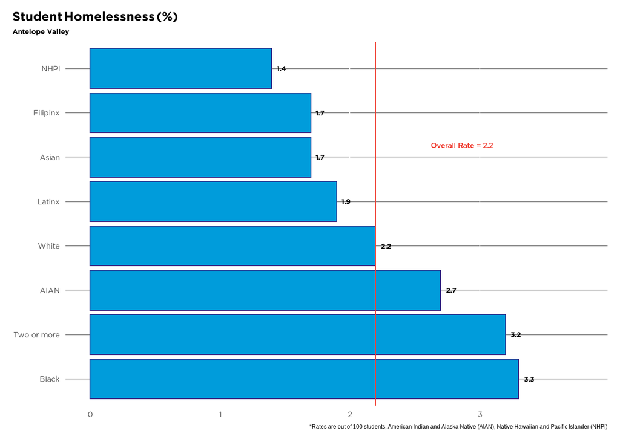

```r
# AV Bar Chart
s <- AV
tot = subset(s, select=c(total_rate)) %>% round(1)  # pull out total_rate
s = subset(s, select=-c(total_rate)) # pull out raced rates
oldnames = c("nh_black_rate","nh_aian_rate", "nh_asian_rate", "nh_filipino_rate", "latino_rate", "nh_pacisl_rate", "nh_white_rate", "nh_twoormor_rate")
engvar = c("Black", "AIAN", "Asian", "Filipinx", "Latinx", "NHPI", "White", "Two or more")
s = s %>% rename_at(vars(oldnames), ~ engvar)

# create english / spanish labels
engvar = c("Black", "AIAN", "Asian", "Filipinx", "Latinx", "NHPI", "White", "Two or more")
esvar = c("Negro", "Indígena Americano", "Asiático", "Filipino", "Latino", "Isleño del Pacifico", "Blanco", "Dos o mas")
#esvar_long = c("NEGRO O AFROAMERICANO", "INDÍGENA AMERICANO O NATIVO DE ALASKA", "ASIÁTICO", "FILIPINO", "LATINO", "ISLEÑO DEL PACIFICO", "BLANCO", "DOS O MAS")
labels <- data.frame(engvar, esvar)
# labels


# convert df to long format
s_long <- reshape2::melt(s, id.vars=c("geoname"))
# Round 'value' field to 1 decimal, rename 'variable' field, add Spanish labels
s_long <- s_long %>% mutate(value = round(value, 1)) %>% dplyr::rename(engvar = variable)  %>%
  left_join(labels, by = "engvar")
s_long <- s_long %>% filter(value > 0)


df <- data.frame(s_long, tot)       # add total_rate to long table
df <- na.omit(df)             # drop NA's
# df

engtot_stat <- paste("Overall Rate =", min(df$total_rate))   # total_rate line annotation
estot_stat <- paste("Promedio Total =", min(df$total_rate))   # total_rate line annotation


# Set region name for file name
region <- "Antelope Valley"


# write the name of your indicator here:
var <- "student_homelessness"


# Define chart height as max y value varies by indicator. Set vertical position for total line label - may need to be customized for each chart.
max_y = 1.15 * max(df$value)
annotate_y = 1.12 * df$total_rate

# specify language: comment out based on language of chart created below
lang <- "eng"

# # ggplot method that should export as .svg ##
av_plot <-
  #English
  ggplot(df, aes(x= reorder(engvar, -value), y=value)) +     # set up manual fill using 'test', add "-" before value to order bars when MAX is best
  annotate("text", x=6.25, y = annotate_y, label = str_wrap(engtot_stat, width = 20), hjust=-0.33, vjust = 0.35, family= font_table_text, color = red) +
  labs(title = "**<span style='font-size:20pt;'>Student Homelessness (%)</span>**", subtitle = region, caption = "*Rates are out of 100 students, American Indian and Alaska Native (AIAN), Native Hawaiian and Pacific Islander (NHPI)") +
  # rest of chart
  geom_bar(stat="identity", position = position_dodge(0.7), show.legend = FALSE) +
  geom_col(fill = lightblue, color = darkblue) +         # all bars in "#355C7D"
  geom_hline(aes(yintercept = round(total_rate, 1)), color = red, size = .5) +
  geom_text(aes(label = round(value, digits = 1)), family = font_bar_label, hjust = -.5) +       # format data labels, adjust hjust to avoid overlap w/ total line
  # scale_y_continuous(limits = c(0, max_y), breaks = seq(0, max_y, by = 20)) +
  scale_x_discrete(labels = function(engvar) str_wrap(engvar, width = 20)) +            # wrap long labels
  xlab("") +
  ylab("") +
  coord_flip()
# av_plot

av_plot <- av_plot + theme(
  panel.background = element_rect(fill = "transparent"), # bg of the panel
  plot.background = element_rect(fill = 'transparent', color=NA),
  panel.grid.major.y = element_line(colour = textgrey),    # add major y-axis gridlines
  panel.grid.minor = element_blank(), # bg of the plot
  axis.title.x = element_blank(),
  axis.title.y = element_blank(),
  axis.text.x = element_text(size = 12, family= font_axis_label),
  axis.text.y = element_text(size = 12, family= font_axis_label),
  axis.ticks = element_blank(),
  plot.title = element_markdown(family = font_title, face = "bold", size = 15, hjust = 0),
  plot.title.position = "plot",
  plot.subtitle = element_text(family = font_title, hjust = 0),
  plot.margin = margin(t = 10,
                       b = 10,
                       r = 10,
                       l = 10)
)


av_plot <- av_plot + ylim(0, max_y)     # add buffer between title and chart/data labels
av_plot
```

Source: [California Department of Education, 2016-2022](https://dq.cde.ca.gov/dataquest/)

## Homelessness

The 2022 Los Angeles County homeless count counted over 65,000 homeless people in Los Angeles County, 1,000 of whom lived in the cities of Lancaster and Palmdale.Thousands more homeless residents live just outside city boundaries in the Antelope Valley (SPA 1). **LAHSA counted 4,598 Antelope Valley homeless persons in 2022 including 3,570 unsheltered and 1,028 sheltered persons.** Another way to break that 4,500+ homeless population shows that figure is made up of 3,681 individuals, 910 family members, and 7 unaccompanied minors.A [Vice News Report](https://www.youtube.com/watch?v=LzbU-9L1WS4) details that law enforcement contributes to moving homeless persons outside of city boundaries and into the broader region.

**Adult & youth sheltered and adult unsheltered in Antelope Valley geographies, 2022**

```r
source("W:/Project/RDA Team/Region 5 State of the Child/R/homeless.R")

library(kableExtra)
kbl(av_table) %>%
  kable_styling(bootstrap_options = c("striped", "bordered", "condensed"))
```

| name | Adult & youth sheltered & adult unsheltered |
| --- | --- |
| Lake Los Angeles | 391 |
| Lancaster | 636 |
| Littlerock/Juniper Hills | 67 |
| Littlerock/Pearblossom | 381 |
| North Lancaster | 29 |
| Palmdale | 309 |
| Pearblossom/Llano | 116 |
| Unincorporated Palmdale | 5 |
| Los Angeles County | 65111 |

Source: [Los Angeles Homeless Services Authority, 2022](https://www.lahsa.org/data)

## Students with Disabilities

Overall in the Antelope Valley, 15% of students have disabilities in the 2021-22 school year, 2.5 percentage points higher than the state average.[2](https://lao.ca.gov/reports/2019/4110/overview-spec-ed-110619.pdf) The percentage of students with disabilities in the Antelope Valley has steadily increased by 2.7 percentage points since the 2015-16 school year. In particular, the Acton-Agua Dulce Unified and Antelope Valley Union High School Districts have above AV average rates of students with disabilities, 16.5% and 17.2% respectively. Given the extremely large number of students with disabilities, the Antelope Valley has an urgent priority need for additional resources for students with disabilities.

**Students with Disabilities Counts by School District 2021-22 School Year**

```r
source("W:/Project/RDA Team/Region 5 State of the Child/R/disabilties.R")
library(kableExtra)
av_table <- av_table %>% mutate(across(c(`2021-22 Count`), comma))
kbl(av_table) %>%
  kable_styling(bootstrap_options = c("striped", "bordered", "condensed"))
```

| Geography | 2021-22 Count | Rate (%) |
| --- | --- | --- |
| Antelope Valley Best Start Region 5 | 13,103 | 15.1 |
| Acton-Agua Dulce Unified School District | 1,963 | 16.5 |
| Antelope Valley Union Joint High School District | 3,972 | 17.2 |
| Eastside Union Elementary School District | 392 | 12.5 |
| Hughes-Elizabeth Lakes Union Elementary School District | 18 | 11.1 |
| Keppel Union Elementary School District | 413 | 14.6 |
| Lancaster Elementary School District | 2,089 | 14.1 |
| Palmdale Elementary School District | 2,971 | 14.2 |
| Westside Union Elementary School District | 1,128 | 12.7 |
| Wilsona Elementary School District | 157 | 12.8 |

Source: [California Department of Education, 2016-2022](https://dq.cde.ca.gov/dataquest/)

## Languages of Children and Families

According to the latest American Community Survey data calculated by Lucy Wilkerson, the Antelope Valley has a diverse set of language speakers. The East Antelope Valley and Palmdale areas have a larger shares of Spanish speakers than the County or State as a whole. There are relatively fewer speakers of Asian or Pacific Islander languages, with West Antelope Valley having the largest share of this group.

**Language Spoken at Home for Antelope Valley geographies, 2020**

```r
source("W:/Project/RDA Team/Region 5 State of the Child/R/language.R")

library(kableExtra)
kbl(data) %>%
  kable_styling(bootstrap_options = c("striped", "bordered", "condensed"))
```

| Geography | English (%) | Spanish (%) | Asian or Pacific Islander language (%) | Other Indo-European language (%) |
| --- | --- | --- | --- | --- |
| LANCASTER | 72.1 | 23.3 | 2.4 | 1.1 |
| PALMDALE | 53.8 | 41.5 | 2.8 | 1.6 |
| EAST ANTELOPE VALLEY | 45.6 | 51.5 | 1.2 | 1.5 |
| WEST ANTELOPE VALLEY | 89.0 | 6.4 | 4.4 | 0.3 |
| LAKE LOS ANGELES | 65.0 | 34.3 | 0.3 | 0.3 |
| QUARTZ HILL | 77.8 | 17.4 | 2.3 | 1.8 |
| ANTELOPE VALLEY BEST START REGION 5 | 62.7 | 32.8 | 2.5 | 1.3 |
| LOS ANGELES COUNTY | 43.9 | 38.7 | 10.8 | 5.4 |
| CALIFORNIA | 56.1 | 28.3 | 10.0 | 4.5 |

Source: [American Community Survey 2016-2020 5-year estimates (population age 5 and over) calculated for Antelope Valley neighborhoods by Lucy Wilkerson](https://public.tableau.com/app/profile/luz3725/viz/2020CensusData-AVBESTSTARTREGION5/GRAPI)

## English Language Learners

**English Language Learner Rates out of 100 by School District 2021-22 School Year**

```r
source("W:/Project/RDA Team/Region 5 State of the Child/R/ell.R")
library(kableExtra)
av_table <- av_table %>% mutate(across(c(`2021-22 Count`), comma))
kbl(av_table) %>%
  kable_styling(bootstrap_options = c("striped", "bordered", "condensed"))
```

| Geography | 2021-22 Count | Rate (%) |
| --- | --- | --- |
| Antelope Valley Best Start Region 5 | 12,397 | 14.3 |
| Acton-Agua Dulce Unified School District | 888 | 7.5 |
| Antelope Valley Union Joint High School District | 2,446 | 10.6 |
| Eastside Union Elementary School District | 660 | 21.1 |
| Hughes-Elizabeth Lakes Union Elementary School District | 4 | 2.5 |
| Keppel Union Elementary School District | 830 | 29.3 |
| Lancaster Elementary School District | 1,985 | 13.4 |
| Palmdale Elementary School District | 4,507 | 21.5 |
| Westside Union Elementary School District | 678 | 7.6 |
| Wilsona Elementary School District | 399 | 32.5 |

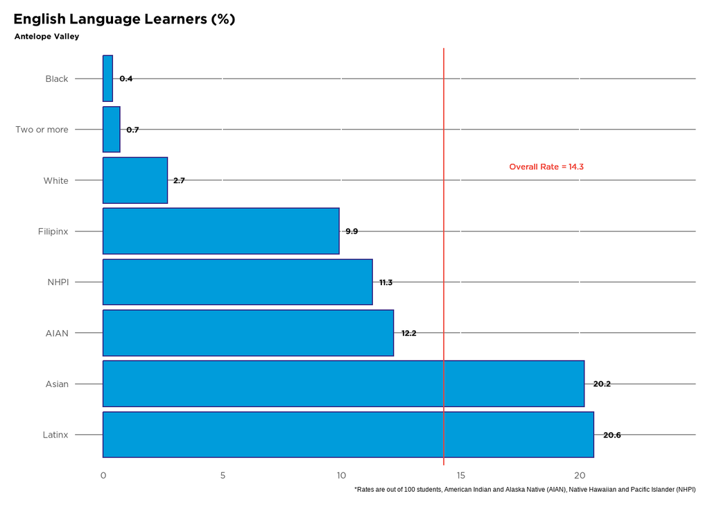

```r
# AV Bar Chart
s <- AV
tot = subset(s, select=c(total_rate)) %>% round(1)  # pull out total_rate
s = subset(s, select=-c(total_rate)) # pull out raced rates
oldnames = c("nh_black_rate","nh_aian_rate", "nh_asian_rate", "nh_filipino_rate", "latino_rate", "nh_pacisl_rate", "nh_white_rate", "nh_twoormor_rate")
engvar = c("Black", "AIAN", "Asian", "Filipinx", "Latinx", "NHPI", "White", "Two or more")
s = s %>% rename_at(vars(oldnames), ~ engvar)

# create english / spanish labels
engvar = c("Black", "AIAN", "Asian", "Filipinx", "Latinx", "NHPI", "White", "Two or more")
esvar = c("Negro", "Indígena Americano", "Asiático", "Filipino", "Latino", "Isleño del Pacifico", "Blanco", "Dos o mas")
#esvar_long = c("NEGRO O AFROAMERICANO", "INDÍGENA AMERICANO O NATIVO DE ALASKA", "ASIÁTICO", "FILIPINO", "LATINO", "ISLEÑO DEL PACIFICO", "BLANCO", "DOS O MAS")
labels <- data.frame(engvar, esvar)
# labels


# convert df to long format
s_long <- reshape2::melt(s, id.vars=c("geoname"))
# Round 'value' field to 1 decimal, rename 'variable' field, add Spanish labels
s_long <- s_long %>% mutate(value = round(value, 1)) %>% dplyr::rename(engvar = variable)  %>%
  left_join(labels, by = "engvar")
s_long <- s_long %>% filter(value > 0)


df <- data.frame(s_long, tot)       # add total_rate to long table
df <- na.omit(df)             # drop NA's
# df

engtot_stat <- paste("Overall Rate =", min(df$total_rate))   # total_rate line annotation
estot_stat <- paste("Promedio Total =", min(df$total_rate))   # total_rate line annotation


# Set region name for file name
region <- "Antelope Valley"


# write the name of your indicator here:
var <- "English Language Learners"

# Define chart height as max y value varies by indicator. Set vertical position for total line label - may need to be customized for each chart.
max_y = 1.15 * max(df$value)
annotate_y = 1.12 * df$total_rate

# specify language: comment out based on language of chart created below
lang <- "eng"


# # ggplot method that should export as .svg ##
av_plot <-
  #English
  ggplot(df, aes(x= reorder(engvar, -value), y=value)) +     # set up manual fill using 'test', add "-" before value to order bars when MAX is best
  annotate("text", x=6.25, y = annotate_y, label = str_wrap(engtot_stat, width = 20), hjust=-0.33, vjust = 0.35, family= font_table_text, color = red) +
  labs(title = "**<span style='font-size:20pt;'>English Language Learners (%)</span>**", subtitle = region, caption = "*Rates are out of 100 students, American Indian and Alaska Native (AIAN), Native Hawaiian and Pacific Islander (NHPI)") +
  # rest of chart
  geom_bar(stat="identity", position = position_dodge(0.7), show.legend = FALSE) +
  geom_col(fill = lightblue, color = darkblue) +         # all bars in "#355C7D"
  geom_hline(aes(yintercept = round(total_rate, 1)), color = red, size = .5) +
  geom_text(aes(label = round(value, digits = 1)), family = font_bar_label, hjust = -.5) +       # format data labels, adjust hjust to avoid overlap w/ total line
  # scale_y_continuous(limits = c(0, max_y), breaks = seq(0, max_y, by = 20)) +
  scale_x_discrete(labels = function(engvar) str_wrap(engvar, width = 20)) +            # wrap long labels
  xlab("") +
  ylab("") +
  coord_flip()
# av_plot

av_plot <- av_plot + theme(
  panel.background = element_rect(fill = "transparent"), # bg of the panel
  plot.background = element_rect(fill = 'transparent', color=NA),
  panel.grid.major.y = element_line(colour = textgrey),    # add major y-axis gridlines
  panel.grid.minor = element_blank(), # bg of the plot
  axis.title.x = element_blank(),
  axis.title.y = element_blank(),
  axis.text.x = element_text(size = 12, family= font_axis_label),
  axis.text.y = element_text(size = 12, family= font_axis_label),
  axis.ticks = element_blank(),
  plot.title = element_markdown(family = font_title, face = "bold", size = 15, hjust = 0),
  plot.title.position = "plot",
  plot.subtitle = element_text(family = font_title, hjust = 0),
  plot.margin = margin(t = 10,
                       b = 10,
                       r = 10,
                       l = 10)
)


av_plot <- av_plot + ylim(0, max_y)     # add buffer between title and chart/data labels
av_plot
```

Source: [California Department of Education, 2016-2022](https://dq.cde.ca.gov/dataquest/)

# Resources (and barriers to access)

Antelope Valley stakeholders have been clear about the need for additional resources, including health and mental health services, early childhood education, and parks and recreation.

## Early Childhood Education

**Unmet need for infant/toddler and preschool-aged children, 2020**

```r
# drv <- dbDriver("PostgreSQL")
#
# con <- dbConnect(drv, dbname = "region5stateofthechild",
#                    host = "aws-postgres-db.c5udgz7ro8hq.us-west-2.rds.amazonaws.com", port = 5432,
#                    user = "postgres", password = pw)

source("W:\\RDA Team\\R\\credentials_source.R")
con <- connect_to_db("region5stateofthechild")

ece_access_it_2020 <- st_read(con, query = "SELECT zipcode, neighborhood, unmet_need_children_it, pct_unmet_need_children_it FROM data.ece_access_it_2020")

ece_access_it_2020 <- ece_access_it_2020 %>% rename(
  "ZIP code" = zipcode,
  "Neighborhood" = neighborhood,
  "Unmet need for infant/toddler care" = unmet_need_children_it,
  "% of infant/toddlers with unmet need" = pct_unmet_need_children_it
)

ece_access_it_2020$Neighborhood <- gsub('[{]', '', ece_access_it_2020$Neighborhood)
ece_access_it_2020$Neighborhood <- gsub('[}]', '', ece_access_it_2020$Neighborhood)
ece_access_it_2020$Neighborhood <- gsub('["]', '', ece_access_it_2020$Neighborhood)
ece_access_it_2020$Neighborhood <- gsub('[,]', ', ', ece_access_it_2020$Neighborhood)

ece_access_prek_2020 <- st_read(con, query = "SELECT zipcode, neighborhood, unmet_need_children_prek, pct_unmet_need_children_prek FROM data.ece_access_prek_2020")

ece_access_prek_2020 <- ece_access_prek_2020 %>% rename(
  "ZIP code" = zipcode,
  "Neighborhood" = neighborhood,
  "Unmet need for preschool" = unmet_need_children_prek,
  "% of preschoolers with unmet need" = pct_unmet_need_children_prek
)

ece_access_prek_2020$Neighborhood <- gsub('[{]', '', ece_access_prek_2020$Neighborhood)
ece_access_prek_2020$Neighborhood <- gsub('[}]', '', ece_access_prek_2020$Neighborhood)
ece_access_prek_2020$Neighborhood <- gsub('["]', '', ece_access_prek_2020$Neighborhood)
ece_access_prek_2020$Neighborhood <- gsub('[,]', ', ', ece_access_prek_2020$Neighborhood)

library(kableExtra)
kbl(ece_access_it_2020) %>%
  kable_styling(bootstrap_options = c("striped", "bordered", "condensed"))
```

| ZIP code | Neighborhood | Unmet need for infant/toddler care | % of infant/toddlers with unmet need |
| --- | --- | --- | --- |
| 93551 | Palmdale, Leona Valley, Southeast Antelope Valley | 1800 | 96.46 |
| 93536 | Northwest Antelope Valley, Lancaster | 1977 | 95.05 |
| 93552 | Palmdale, Angeles Crest, Southeast Antelope Valley | 1377 | 94.32 |
| 93550 | Tujunga Canyons, Palmdale, Angeles Crest | 2664 | 93.41 |
| 93534 | Lancaster, Northeast Antelope Valley | 1014 | 89.26 |
| 93535 | Northeast Antelope Valley, Lancaster | 1725 | 88.92 |

```r
library(kableExtra)
kbl(ece_access_prek_2020) %>%
  kable_styling(bootstrap_options = c("striped", "bordered", "condensed"))
```

| ZIP code | Neighborhood | Unmet need for preschool | % of preschoolers with unmet need |
| --- | --- | --- | --- |
| 93551 | Palmdale, Leona Valley, Southeast Antelope Valley | 1779 | 88.99 |
| 93536 | Northwest Antelope Valley, Lancaster | 2599 | 85.72 |
| 93552 | Palmdale, Angeles Crest, Southeast Antelope Valley | 1330 | 85.15 |
| 93550 | Tujunga Canyons, Palmdale, Angeles Crest | 2429 | 79.59 |
| 93534 | Lancaster, Northeast Antelope Valley | 1284 | 75.57 |
| 93535 | Northeast Antelope Valley, Lancaster | 2034 | 72.13 |

Source: [American Institutes of Research, 2020](https://elneedsassessment.org/)

## Child Welfare

**The Antelope Valley is a County hotspot for high substantiated referral rates.** The average countywide statistical area referral rate in the Antelope Valley is nearly twice the county average (12.2 substantiated referrals per 1,000 children in the Antelope Valley vs. 6.4 per 1,000 in LA County)[1](https://data.lacounty.gov/datasets/lacounty::dcfs-all-substantiated-referrals-2021/explore?location=34.062678%2C-118.298788%2C8.00&showTable=true).

All foster children are required to have a mental health screening [1](https://theacademy.sdsu.edu/wp-content/uploads/2015/01/understanding-cws.pdf), but AV (SPA 1) parents are most likely to report difficulties accessing medical care for their children than parents in all other SPAs. **AV parents reported medical care access difficulties for 16.4% of AV children, whereas LA County parents reported difficulties for 9.3% of county children overall**[1](http://publichealth.lacounty.gov/ha/docs/2018LACHS/MDT/Child/M3_ChildAccessToCare/M3_AccessToHealthCare_CACCDIFF.xlsx).

These parents are part of the larger **adult population that reports highest-among-SPA rates of discrimination when seeking health care. 6.7% of AV adults rated their experience as worse Compared to people of other races when seeking health care in 2018, compared to 3.8% of county adults overall**[1](http://publichealth.lacounty.gov/ha/docs/2018LACHS/MDT/Adult/M3_SocialDeterminantsOfHealth/M3_Discrimination_DISC66HC.xlsx).

On a positive note, there are many services aimed at children and families in the Antelope Valley, including the Black Infant Health Program of Antelope Valley, the Children’s Bureau Sunrise Center, and others who work to ensure families have what they need to thrive.

## Health

According to the [Los Angeles County Health Survey](http://publichealth.lacounty.gov/ha/hasurveyintro.htm), **16.4% of Antelope Valley children report difficulty accessing medical care (highest among county Service Planning Areas or SPAs)**. The Antelope Valley has fewer health and medical professionals than other parts of the county and state. The area has a variety of medical and health professional shortage designations, including:

- The Lake Los Angeles and Juniper Hills Little Rock Medical Services Study Areas (MSSAs) are Medically Underserved Areas[1](https://gis.data.ca.gov/datasets/CHHSAgency::medically-underserved-areas/explore?location=34.269244%2C-118.153917%2C9.58)
- The two MSSAs plus the Lancaster Central/Palmdale North Central and Palmdale Central MSSAs are Primary Care Health Professional Shortage Areas[1](https://gis.data.ca.gov/datasets/CHHSAgency::health-professional-shortage-area-primary-care/explore?location=34.384784%2C-117.925067%2C9.00)
- These four MSSAs plus the Acton/Ravenna, Desert View Highlands/Lancaster West/Palmdale Northwest/Quartz Hill, and Elizabeth Lake/Gorman/Green Valley/Lake Hughes/Leona Valley/Neenach MSSAs are mental health professional shortage areas[1](https://gis.data.ca.gov/datasets/CHHSAgency::health-professional-shortage-area-mental-health/explore?location=34.300335%2C-118.134212%2C9.00). This means that virtually the entire Antelope Valley is a mental health professional shortage areas.

Source: California Health and Human Services Geospatial Data portal for [Medically Underserved Areas](https://gis.data.ca.gov/datasets/CHHSAgency::medically-underserved-areas/explore?location=34.514402%2C-118.185118%2C9.58) and [Primary Care Health Professional](https://gis.data.ca.gov/datasets/CHHSAgency::health-professional-shortage-area-primary-care/explore?location=34.380830%2C-117.925067%2C9.00) and [Mental Health Professional](https://gis.data.ca.gov/datasets/CHHSAgency::health-professional-shortage-area-mental-health/explore?location=34.296386%2C-118.134212%2C9.00) Shortages Areas.

Health and mental health outcomes might suffer because of the lack of services. Medical care can be especially important for chronic conditions that need periodic treatment such as asthma. Antelope Valley adults are most likely to say they’ve ever seriously thought about committing suicide, 13% of the AV adult population, compared to 9.8% of LA County residents overall.[1](https://ask.chis.ucla.edu/)

12.2% of Antelope Valley children have been diagnosed with asthma at some point in their lives (a higher percentage than the 11.1% county total), meaning access to health care is important for the Antelope Valley population.

## Parks

The Los Angeles County County Department of Parks and Recreation completed a Countywide Parks and Recreation Needs Assessment addition in 2022. The assessment has findings for the region in an [Antelope Valley regional profile](https://lacountyparkneeds.org/wp-content/uploads/2022/11/AppA_RegionalProfiles_AntelopeValley_11282022.pdf). Some key findings from that profile:

- The regional recreation facilities and trails in the area are poorly served by public transportation and largely inaccessible without the use of a personal vehicle.
- The highest Regional Recreation Need is found in Lake Los Angeles, Littlerock, and Sun Village due to a combination of social and environmental factors.
- Community members identified heat, distance, safety, lack of information and limited facilities as barriers to park use for residents in the study area.
- **Residents say they need more shade, cooling centers and access to water, affordable transit access to parks, additional facilities and programming, enhanced safety measures and more information about parks and amenities**.

# Economics

## Rent Burden (Cost Burden Renter)

**Rent Burden Rates out of 100 by AV Neighborhood 2016-2020 (30% or more of income spent on rent)**

```r
source("W:/Project/RDA Team/Region 5 State of the Child/R/rent_burden_totals.R")
library(kableExtra)
kbl(av_table) %>%
 kable_styling(bootstrap_options = c("striped", "bordered", "condensed"))
```

| NEIGHBORHOOD | Rent_Burdened |
| --- | --- |
| ANTELOPE VALLEY BEST START REGION 5 | 59.2% |
| EAST ANTELOPE VALLEY | 62.3% |
| LAKE LOS ANGELES | 59.5% |
| LANCASTER | 59.5% |
| PALMDALE | 59.7% |
| QUARTZ HILL | 43.7% |
| WEST ANTELOPE VALLEY | 77.8% |

Source: [American Community Survey 2016-2020 5-year estimates calculated for Antelope Valley neighborhoods by Lucy Wilkerson](https://public.tableau.com/app/profile/luz3725/viz/2020CensusData-AVBESTSTARTREGION5/GRAPI)

## Foreclosures

Foreclosure data was calculated using 2017 to partial 2022 data. In this time period there were a total of 546 foreclosures in the Antelope Valley Region. On average 1 out of 2,500 (or 3.8 out of 10,000) owner households in the AV faced foreclosures.

Although by rate, Lancaster and Palmdale did not have the highest rate of foreclosures, these two locations have the the greatest populations in the AV. Thus, they still had the most foreclosures by count, 239 and 181 respectively.

** Foreclosure Totals by Region and Neighborhood **

```r
source("W:/Project/RDA Team/Region 5 State of the Child/R/foreclosure.R")

library(kableExtra)
kbl(av_table) %>%
  kable_styling(bootstrap_options = c("striped", "bordered", "condensed"))
```

|  | Geography | Total Count | Total Households | Avg Foreclosure Rate Per 10K Households |
| --- | --- | --- | --- | --- |
| 7 | AV BEST START REGION 5 | 546 | 64730 | 3.834108 |
| 3 | EAST ANTELOPE VALLEY | 28 | 2861 | 4.448540 |
| 5 | LAKE LOS ANGELES | 57 | 2221 | 11.665507 |
| 1 | LANCASTER | 239 | 25620 | 4.240295 |
| 2 | PALMDALE | 181 | 29728 | 2.767516 |
| 6 | QUARTZ HILL | 41 | 3707 | 5.027344 |
| 4 | WEST ANTELOPE VALLEY | 0 | 593 | 0.000000 |

Source: [DataQuick (2017 to partial 2022) purchased from DQNews](https://dqnews.com.cutestat.com/)

## Evictions

To calculate evictions, 2013-2017 data was used due to the limitations of available data. There have been 636 evictions in the AV between 2013-2017. Meaning 1 out of 50 households in the AV faced evictions during this time period. This is twice the rate of California and more than twice the rate of Los Angeles County where 1 in 100 households and 0.8 in 100 households face evictions respectively[1](https://www.racecounts.org/). By rate, Lake Los Angeles had the most evictions while Quartz Hill had the least. The neighborhoods of Lancaster (350 evictions) and Palmdale (226 evictions) had the most evictions by count. About half of all evictions during this time period were in Lancaster.

** Eviction Totals by Region and Neighborhood **

```r
source("W:/Project/RDA Team/Region 5 State of the Child/R/eviction.R")

library(kableExtra)

kbl(av_count2) %>%
  kable_styling(bootstrap_options = c("striped", "bordered", "condensed"))
```

| Geography | Total Rate Per 100 People (%) | Total Households | Eviction Count |
| --- | --- | --- | --- |
| ANTELOPE VALLEY BEST START REGION 5 | 2.02 | 31465 | 636 |
| EAST ANTELOPE VALLEY | NA | 714 | 5 |
| LAKE LOS ANGELES | 2.12 | 1181 | 25 |
| LANCASTER | 1.87 | 17448 | 350 |
| PALMDALE | 1.99 | 10720 | 226 |
| QUARTZ HILL | 1.75 | 1402 | 30 |

Source: [Eviction Lab with ACS 2013-2017, 2020](https://data-downloads.evictionlab.org/#data-for-analysis/)

## Cost of Living

According to the United Ways of California, **roughly half of households in and around Lancaster and Palmdale do not earn sufficient incomes to meet their basic costs of living** (i.e., they earn incomes below the real cost measure of living). Lancaster and Palmdale adjusted median household incomes are well below other parts of the County and State.

**Households below the real cost of living and median household income, 2019**

```r
source("W:/Project/RDA Team/Region 5 State of the Child/R/cost_of_living.R")

library(kableExtra)
kbl(rcm_data) %>%
  kable_styling(bootstrap_options = c("striped", "bordered", "condensed"))
```

| Geography | % Households Below RCM | % White Households Below RCM | % Black Households Below RCM | % Latino Households Below RCM | % Households with a child under 6 Below RCM | Median Adjusted Household Income |
| --- | --- | --- | --- | --- | --- | --- |
| Los Angeles County (North Central)–Lancaster City | 55.3 | 37.7 | 66.6 | 69.1 | 82.7 | $67,680 |
| Los Angeles County (North Central)–Palmdale City | 49.5 | 36.8 | NA | 56.7 | 83.2 | $72,680 |
| Los Angeles County | 39.6 | 22.3 | 43.0 | 57.7 | 61.2 | $82,832 |
| State of California | 32.6 | 20.6 | 41.4 | 51.6 | 54.1 | $91,923 |

Source: [United Ways of California Real Cost Measure, 2019](https://www.unitedwaysca.org/realcost/39-real-cost)

## Food Insecurity

Feeding America estimates that 55,110 children are food insecure in Congressional District 25, covering Antelope Valley outside of Lancaster[1](https://map.feedingamerica.org/district/2020/overall/california/district/25). **Over 10,000 Antelope Valley children under 5 participate in WIC**. Latinx children comprise the largest share of Antelope Valley WIC participants, with nearly 1 in 5 Palmdale participants living in a Spanish-only home. Black children make up nearly 1 in 4 Lancaster WIC participants.

**WIC participants by race, Antelope Valley geographies, 2021**

```r
source("W:/Project/RDA Team/Region 5 State of the Child/R/food_security.R")

library(kableExtra)
kbl(wic_data) %>%
  kable_styling(bootstrap_options = c("striped", "bordered", "condensed"))
```

| Geography | Under age 5 | White (%) | Asian (%) | Other (%) | Hispanic - Spanish speaking (%) | Hispanic - English speaking (%) | Black (%) |
| --- | --- | --- | --- | --- | --- | --- | --- |
| Best Start - Lancaster | 4464 | 5.1 | 0.6 | 5.3 | 12.0 | 52.7 | 24.4 |
| Best Start - Palmdale | 5449 | 3.0 | 0.6 | 2.7 | 19.4 | 61.4 | 12.9 |
| Service Planning Area 1 - Antelope Valley | 10278 | 4.3 | 0.6 | 4.0 | 16.1 | 57.3 | 17.7 |
| Supervisor District 5 | 25228 | 2.6 | 5.7 | 4.3 | 18.0 | 62.2 | 7.2 |
| Los Angeles County | 211170 | 3.9 | 2.8 | 3.9 | 26.6 | 55.1 | 7.5 |

Source: [L.A. County WIC Administrative Data, 2021](https://lawicdata.org/data-research/by-region/)

# Education

## Highschool Graduation

In the Antelope Valley female Students graduation rates (72%) were 10 percentage points higher than their male counterparts (62%). About half of students with Disabilities (51%), English Language Learners (50%), and students in Foster Care (47%) were able to graduate in the AV. Students experiencing homelessness fared far worse with only 38% or 19 out of 50 students graduating from High School. According to the CDE students in the Migrant program had a much higher graduation rate with 89% graduating. However this number does not account for migrant students who are not registered in the Migrant Program. Students that the CDE considered Socioeconomically Disadvantaged (65%) around the total average (67%) which makes sense since the majority of the student population in the AV is considered to Socioeconomically Disadvantaged (82%).

```r
source("W:/Project/RDA Team/Region 5 State of the Child/R/hs_grad.R")
library(kableExtra)


kbl(av_table) %>%
 kable_styling(bootstrap_options = c("striped", "bordered", "condensed"))
```

| Adjusted 5-Year 2020-2021 | Female | Male | Asian | Black | Filipino | Latinx | AIAN | Two or More Races | White | Disability | ELL | Foster | Homeless | Migrant | Socioeconomically Disadvantaged | Total |
| --- | --- | --- | --- | --- | --- | --- | --- | --- | --- | --- | --- | --- | --- | --- | --- | --- |
| Total Rate | 72.4 | 62 | 87 | 65.7 | 81.2 | 65.7 | 70.3 | 75.1 | 74.6 | 51 | 49.6 | 47.2 | 37.5 | 89.1 | 64.6 | 67.2 |
| Total Count | 3065.0 | 2640 | 80 | 738.0 | 82.0 | 3661.0 | 9.0 | 244.0 | 853.0 | 725 | 534.0 | 150.0 | 166.0 | 41.0 | 4702.0 | 5711.0 |

Source: [California Department of Education, Adjusted Five-Year Cohort Graduation Rate and Outcome Data, 2020-2021](https://www.cde.ca.gov/ds/ad/filesacgr.asp)

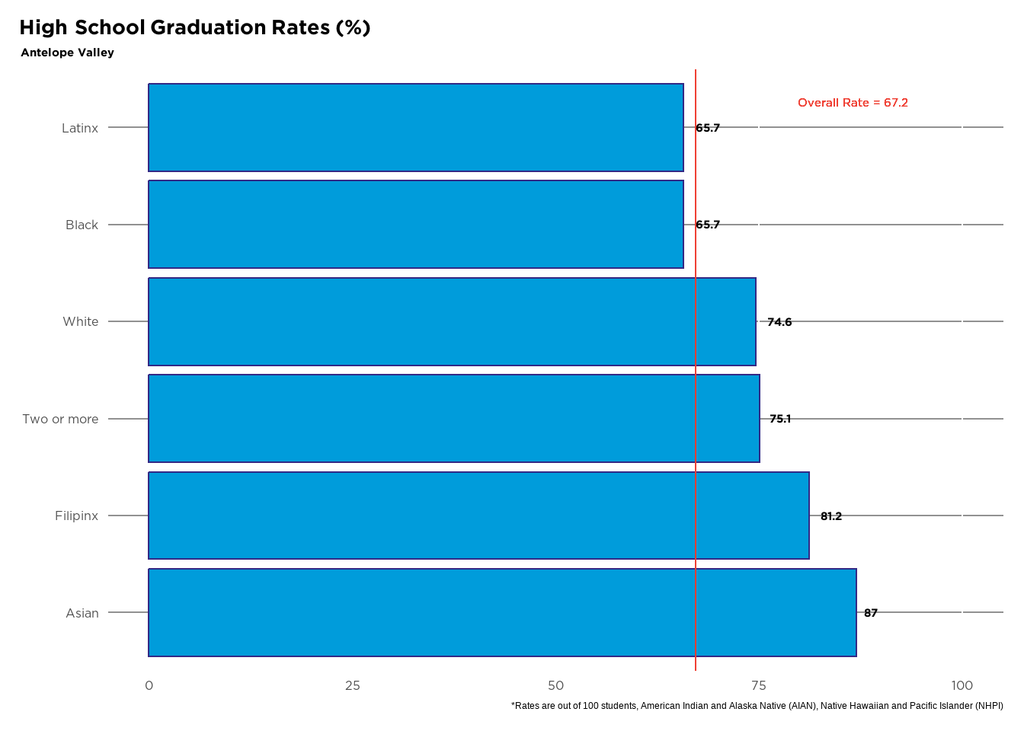

```r
# AV Bar Chart

s <- AV
tot = subset(s, select=c(total_rate)) %>% round(1)  # pull out total_rate
s = subset(s, select=-c(total_rate)) # pull out raced rates
oldnames = c("nh_asian_rate", "nh_black_rate", "nh_filipino_rate", "latino_rate", "nh_twoormor_rate", "nh_white_rate")
engvar = c("Asian", "Black", "Filipinx", "Latinx", "Two or more", "White")
s = s %>% rename_at(vars(oldnames), ~ engvar)

# create english / spanish labels
engvar = c("Black", "AIAN", "Asian", "Filipinx", "Latinx", "NHPI", "White", "Two or more")
esvar = c("Negro", "Indígena Americano", "Asiático", "Filipino", "Latino", "Isleño del Pacifico", "Blanco", "Dos o mas")
#esvar_long = c("NEGRO O AFROAMERICANO", "INDÍGENA AMERICANO O NATIVO DE ALASKA", "ASIÁTICO", "FILIPINO", "LATINO", "ISLEÑO DEL PACIFICO", "BLANCO", "DOS O MAS")
labels <- data.frame(engvar, esvar)
# labels


# convert df to long format
s_long <- reshape2::melt(s, id.vars=c("geoname"))
# Round 'value' field to 1 decimal, rename 'variable' field, add Spanish labels
s_long <- s_long %>% mutate(value = round(value, 1)) %>% dplyr::rename(engvar = variable)  %>%
  left_join(labels, by = "engvar")
s_long <- s_long %>% filter(value > 0)


df <- data.frame(s_long, tot)       # add total_rate to long table
df <- na.omit(df)             # drop NA's
# df

engtot_stat <- paste("Overall Rate =", min(df$total_rate))   # total_rate line annotation
estot_stat <- paste("Promedio Total =", min(df$total_rate))   # total_rate line annotation


# Set region name for file name
region <- "Antelope Valley"


# write the name of your indicator here:
var <- "hs_graduation"


# Define chart height as max y value varies by indicator. Set vertical position for total line label - may need to be customized for each chart.
max_y = 1.15 * max(df$value)
annotate_y = 1.12 * (df$total_rate)

# specify language: comment out based on language of chart created below
lang <- "eng"




# # ggplot method that should export as .svg ##
av_plot <-
  #English
  ggplot(df, aes(x= reorder(engvar, -value), y=value)) +     # set up manual fill using 'test', add "-" before value to order bars when MAX is best
  annotate("text", x=6.25, y = annotate_y, label = str_wrap(engtot_stat, width = 20), hjust=-0.33, vjust = 0.35, family= font_table_text, color = red) +
  labs(title = "**<span style='font-size:20pt;'>High School Graduation Rates (%)</span>**", subtitle = region, caption = "*Rates are out of 100 students, American Indian and Alaska Native (AIAN), Native Hawaiian and Pacific Islander (NHPI)") +
  # rest of chart
  geom_bar(stat="identity", position = position_dodge(0.7), show.legend = FALSE) +
  geom_col(fill = lightblue, color = darkblue) +         # all bars in "#355C7D"
  geom_hline(aes(yintercept = round(total_rate, 1)), color = red, size = .5) +
  geom_text(aes(label = round(value, digits = 1)), family = font_bar_label, hjust = -.5) +       # format data labels, adjust hjust to avoid overlap w/ total line
  # scale_y_continuous(limits = c(0, max_y), breaks = seq(0, max_y, by = 20)) +
  scale_x_discrete(labels = function(engvar) str_wrap(engvar, width = 20)) +            # wrap long labels
  xlab("") +
  ylab("") +
  coord_flip()
# av_plot

av_plot <- av_plot + theme(
  panel.background = element_rect(fill = "transparent"), # bg of the panel
  plot.background = element_rect(fill = 'transparent', color=NA),
  panel.grid.major.y = element_line(colour = textgrey),    # add major y-axis gridlines
  panel.grid.minor = element_blank(), # bg of the plot
  axis.title.x = element_blank(),
  axis.title.y = element_blank(),
  axis.text.x = element_text(size = 12, family= font_axis_label),
  axis.text.y = element_text(size = 12, family= font_axis_label),
  axis.ticks = element_blank(),
  plot.title = element_markdown(family = font_title, face = "bold", size = 15, hjust = 0),
  plot.title.position = "plot",
  plot.subtitle = element_text(family = font_title, hjust = 0),
  plot.margin = margin(t = 10,
                       b = 10,
                       r = 10,
                       l = 10)
)


av_plot <- av_plot + ylim(0, max_y)     # add buffer between title and chart/data labels
av_plot
```

Source: [California Department of Education, Adjusted Cohort Graduation Rate and Outcome Data, 2016-2022](https://www.cde.ca.gov/ds/ad/filesacgr.asp)

## Teacher & Staff Diversity

The most recent California Department of Education data on certificated staff is from the 2018-19 school year. It shows that **the majority of AV school district students are Latinx but see relatively few Latinx teachers**. In that year White students made up 13.4% of enrolled students and White staff made up 69.4% of certificated staff. By contrast Latinx students made up 63.2% of enrolled students and Latinx staff made up 17.9% of certificated staff

**Shares of student enrollment & certificated staff in Antelope Valley schools, 2018-19**

```r
# drv <- dbDriver("PostgreSQL")
#
# con <- dbConnect(drv, dbname = "region5stateofthechild",
#                    host = "aws-postgres-db.c5udgz7ro8hq.us-west-2.rds.amazonaws.com", port = 5432,
#                    user = "postgres", password = pw)

source("W:\\RDA Team\\R\\credentials_source.R")
con <- connect_to_db("region5stateofthechild")

av_staff_student_race <- st_read(con, query = "SELECT * FROM av_staff_student_race")

library(kableExtra)
kbl(av_staff_student_race) %>%
  kable_styling(bootstrap_options = c("striped", "bordered", "condensed"))
```

| race_ethnicity | enrollment | staff | enrollment_rate | staff_rate | rate_difference |
| --- | --- | --- | --- | --- | --- |
| White, not Hispanic | 9668 | 3375 | 13.4 | 69.4 | 56.1 |
| Asian, not Hispanic | 772 | 135 | 1.1 | 2.8 | 1.8 |
| Pacific Islander, not Hispanic | 117 | 17 | 0.2 | 0.4 | 0.2 |
| American Indian or Alaska Native, not Hispanic | 297 | 20 | 0.4 | 0.4 | 0.0 |
| Filipino, not Hispanic | 843 | 51 | 1.2 | 1.1 | -0.1 |
| Two or More Races, not Hispanic | 2557 | 49 | 3.5 | 1.0 | -2.5 |
| African American, not Hispanic | 12313 | 340 | 17.0 | 7.1 | -9.9 |
| Hispanic or Latino | 45736 | 869 | 63.2 | 17.9 | -45.3 |

Source: [California Department of Education, 2018-19](https://www.cde.ca.gov/ds/)

## Chronic Absenteeism

Chronic absenteeism stems for a variety of factors including student-specific, family-specific, school-specific, and community-specific factors, which vary by age. For example, schools that do not engage children and families with work schedules making it difficult to monitor their children’s schooling, are two contributors to absenteeism.[1](https://www.brookings.edu/research/chronic-absenteeism-an-old-problem-in-search-of-new-answers/).

```r
# drv <- dbDriver("PostgreSQL")
#
# con <- dbConnect(drv, dbname = "region5stateofthechild",
#                    host = "aws-postgres-db.c5udgz7ro8hq.us-west-2.rds.amazonaws.com", port = 5432,
#                    user = "postgres", password = pw)

source("W:\\RDA Team\\R\\credentials_source.R")
con <- connect_to_db("region5stateofthechild")

av_chronic_absenteeism_21_22 <- st_read(con, query = "SELECT * FROM av_chronic_absenteeism_21_22")

names(av_chronic_absenteeism_21_22) <- c("Race-ethnicity", "Student enrollment", "Chronically absent students", "Chronic absenteeism rate (%)")

library(kableExtra)
kbl(av_chronic_absenteeism_21_22) %>%
  kable_styling(bootstrap_options = c("striped", "bordered", "condensed"))
```

| Race-ethnicity | Student enrollment | Chronically absent students | Chronic absenteeism rate (%) |
| --- | --- | --- | --- |
| Black | 14757 | 6739 | 45.7 |
| NHPI | 144 | 58 | 40.3 |
| AIAN | 367 | 145 | 39.5 |
| Latinx | 62585 | 23059 | 36.8 |
| Total | 96902 | 35442 | 36.6 |
| Multiracial | 3885 | 1367 | 35.2 |
| White | 12408 | 3502 | 28.2 |
| Asian | 1136 | 175 | 15.4 |
| Filipino | 936 | 143 | 15.3 |

Source: Catalyst California calculations of [California Department of Education, 2021-22](https://www.cde.ca.gov/ds/ad/filesabd.asp) data. Antelope Valley schools are schools from the following districts: Acton-Agua Dulce Unified, Antelope Valley Union High, Eastside Union Elementary, Gorman Joint, Hughes-Elizabeth Lakes Union Elementary, Keppel Union Elementary, Lancaster Elementary, Palmdale Elementary, Westside Union Elementary, and Wilsona Elementary.

## Suspensions

The last full year of in-class learning for which the California Department of Education publishes data is 2021-22. That year **suspension rates for Foster and Black students were more than double the district total suspension rate Antelope Valley school districts**. American Indian or Alaska Native and Multiracial suspension rates were also often above totals in most area school districts.

**Suspension Rates by Student Group, Antelope Valley School Districts, 2021-22**

```r
source("W:/Project/RDA Team/Region 5 State of the Child/R/suspension.R")

library(stringr)
library(kableExtra)
kbl(susp_table) %>%
  kable_styling(bootstrap_options = c("striped", "bordered", "condensed"))
```

| Student group | Student enrollment | Unduplicated count of students suspended | Suspension rate |
| --- | --- | --- | --- |
| Foster | 3203 | 388 | 12.1 |
| African American | 15493 | 1804 | 11.6 |
| Students with Disabilities | 16383 | 1267 | 7.7 |
| American Indian or Alaska Native | 384 | 24 | 6.2 |
| Pacific Islander | 161 | 10 | 6.2 |
| Male | 51270 | 3065 | 6.0 |
| Socioeconomically Disadvantaged | 77770 | 4227 | 5.4 |
| Two or More Races | 3977 | 206 | 5.2 |
| Total | 100391 | 4738 | 4.7 |
| Homeless | 2861 | 133 | 4.6 |
| Migrant | 226 | 10 | 4.4 |
| English Learners | 14378 | 615 | 4.3 |
| Hispanic or Latino | 64817 | 2302 | 3.6 |
| Female | 49022 | 1673 | 3.4 |
| White | 12591 | 358 | 2.8 |
| Not Reported | 759 | 15 | 2.0 |
| Filipino | 953 | 12 | 1.3 |
| Asian | 1197 | 7 | 0.6 |
| Non-Binary Gender | 85 | 0 | 0.0 |

Source: Catalyst California calculations of [California Department of Education, 2021-22](https://www.cde.ca.gov/ds/) data. Antelope Valley schools are schools from the following districts: Acton-Agua Dulce Unified, Antelope Valley Union High, Eastside Union Elementary, Gorman Joint, Hughes-Elizabeth Lakes Union Elementary, Keppel Union Elementary, Lancaster Elementary, Palmdale Elementary, Westside Union Elementary, and Wilsona Elementary.

## 3rd Grade Math Scores

Male students scored proficiently 5.6 percentage points higher than their female counterparts in the AV. Students that were considered Economically Disadvantaged scored proficiently 3.7 percentage points under the total AV average. English Language Learners (14%), students experiencing Homelessness (12.7%), students with disabilities (9.6%), and students in Foster Care (8.7%) all scored proficient results much lower than the AV average, with students in Foster Care scoring the lowest.

**Antelope Valley District Level 3rd Graders Scoring Proficient or Better in Math (%)**

```r
source("W:/Project/RDA Team/Region 5 State of the Child/R/math.R")

library(kableExtra)
kbl(av_table) %>%
  kable_styling(bootstrap_options = c("striped", "bordered", "condensed"))
```

|  | geoname | Total | Male | Female | Economically Disadvantaged | Homeless | Black | Filipino | Latinx | White | Disability | Two or More indicators | ELL | Foster | Asian |
| --- | --- | --- | --- | --- | --- | --- | --- | --- | --- | --- | --- | --- | --- | --- | --- |
| 9 | Antelope Valley Best Start Region 5 | 24.0 | 26.6 | 21.0 | 20.3 | 12.7 | 9.0 | 50.0 | 23.8 | 41.9 | 9.6 | 25.0 | 14.0 | 8.7 | 54.2 |
| 8 | Acton-Agua Dulce Unified School District | 39.6 | 51.9 | 26.9 | 39.4 | NA | NA | NA | 29.6 | 54.5 | NA | NA | NA | NA | NA |
| 1 | Eastside Union Elementary School District | 16.0 | 15.5 | 16.6 | 16.2 | 0.0 | 9.0 | NA | 16.8 | 15.8 | 7.3 | NA | 11.8 | 0.0 | NA |
| 2 | Hughes-Elizabeth Lakes Union Elementary School District | 31.8 | NA | 23.1 | NA | NA | NA | NA | NA | 33.3 | NA | NA | NA | NA | NA |
| 3 | Keppel Union Elementary School District | 28.1 | 28.0 | 28.1 | 27.1 | NA | NA | NA | 27.3 | 37.0 | 6.1 | NA | 18.6 | NA | NA |
| 4 | Lancaster Elementary School District | 19.4 | 22.7 | 15.9 | 17.4 | 10.3 | 7.3 | 58.3 | 21.0 | 37.8 | 8.1 | 24.6 | 10.7 | 9.8 | 63.6 |
| 5 | Palmdale Elementary School District | 22.0 | 24.6 | 19.4 | 20.4 | NA | 8.7 | 18.2 | 23.7 | 34.6 | 8.5 | 24.4 | 13.1 | 8.6 | NA |
| 6 | Westside Union Elementary School District | 36.7 | 40.5 | 32.7 | 26.7 | 19.4 | 20.0 | 76.5 | 31.6 | 49.3 | 17.6 | 31.2 | 26.3 | 13.3 | 65.5 |
| 7 | Wilsona Elementary School District | 18.0 | 21.0 | 14.0 | 17.6 | 15.4 | NA | NA | 18.4 | 30.8 | 7.1 | NA | 11.8 | NA | NA |

Please note that data for AIAN and NHPI groups are not present in the table because of a lack of data for these two groups.

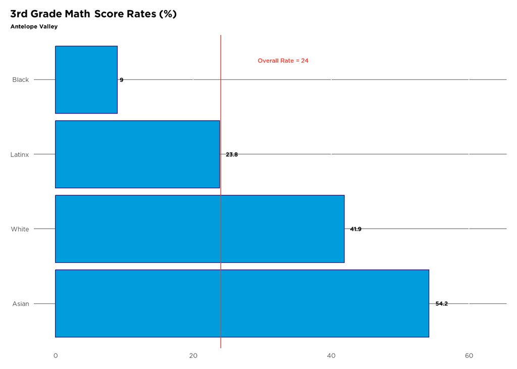

```r
# AV Bar Chart

s <- AV
tot = subset(s, select=c(Total)) # pull out Total
s = subset(s, select=-c(Total)) # pull out raced rates


# create english / spanish labels
engvar = c("Black", "Filipinx", "Latinx", "White", "Two or more", "Asian")
esvar = c("Negro", "Filipino", "Latino", "Blanco", "Dos o mas", "Asiático")

labels <- data.frame(engvar, esvar)
# labels


# convert df to long format
s_long <- reshape2::melt(s, id.vars=c("geoname"))
# Round 'value' field to 1 decimal, rename 'variable' field, add Spanish labels
s_long <- s_long %>% mutate(value = round(value, 1)) %>% dplyr::rename(engvar = variable)  %>%
  left_join(labels, by = "engvar")
s_long <- s_long %>% filter(value > 0)


df <- data.frame(s_long, tot)       # add Total to long table
df <- na.omit(df)             # drop NA's
# df

engtot_stat <- paste("Overall Rate =", min(df$Total))   # Total line annotation
estot_stat <- paste("Promedio Total =", min(df$Total))   # Total line annotation


# Set region name for file name
region <- "Antelope Valley"


# write the name of your indicator here:
var <- "3rd_grade_math"


# Define chart height as max y value varies by indicator. Set vertical position for total line label - may need to be customized for each chart.
max_y = 1.15 * max(df$value)
annotate_y = 1.12 * (df$Total)

# specify language: comment out based on language of chart created below
lang <- "eng"


# # ggplot method that should export as .svg ##
av_plot <-
  #English
  ggplot(df, aes(x= reorder(engvar, -value), y=value)) +     # set up manual fill using 'test', add "-" before value to order bars when MAX is best
  annotate("text", x=4.25, y = annotate_y, label = str_wrap(engtot_stat, width = 20), hjust=-0.33, vjust = 0.35, family= font_table_text, color = red) +
  labs(title = "**<span style='font-size:20pt;'>3rd Grade Math Score Rates (%)</span>**", subtitle = region) +
  # rest of chart
  geom_bar(stat="identity", position = position_dodge(0.7), show.legend = FALSE) +
  geom_col(fill = lightblue, color = darkblue) +         # all bars in "#355C7D"
  geom_hline(aes(yintercept = round(Total, 1)), color = red, size = .5) +
  geom_text(aes(label = round(value, digits = 1)), family = font_bar_label, hjust = -.5) +       # format data labels, adjust hjust to avoid overlap w/ total line
  # scale_y_continuous(limits = c(0, max_y), breaks = seq(0, max_y, by = 20)) +
  scale_x_discrete(labels = function(engvar) str_wrap(engvar, width = 20)) +            # wrap long labels
  xlab("") +
  ylab("") +
  coord_flip()
# av_plot

av_plot <- av_plot + theme(
  panel.background = element_rect(fill = "transparent"), # bg of the panel
  plot.background = element_rect(fill = 'transparent', color=NA),
  panel.grid.major.y = element_line(colour = textgrey),    # add major y-axis gridlines
  panel.grid.minor = element_blank(), # bg of the plot
  axis.title.x = element_blank(),
  axis.title.y = element_blank(),
  axis.text.x = element_text(size = 12, family= font_axis_label),
  axis.text.y = element_text(size = 12, family= font_axis_label),
  axis.ticks = element_blank(),
  plot.title = element_markdown(family = font_title, face = "bold", size = 15, hjust = 0),
  plot.title.position = "plot",
  plot.subtitle = element_text(family = font_title, hjust = 0),
  plot.margin = margin(t = 10,
                       b = 10,
                       r = 10,
                       l = 10)
)


av_plot <- av_plot + ylim(0, max_y)     # add buffer between title and chart/data labels
av_plot
```

## 3rd Grade English Scores

In the AV, female students scored proficiently 6 percentage points higher than their male counterparts. Economically Disadvantaged Students passed at a rate 3.6 percentage points under that of the AV average. Students experiencing homelessness, English Language Learners, and students in Foster Care all scored proficiently 10 percentage points under the AV average. Students with disabilities had the lowest passing rate with only 9.4% getting proficient results.

**Antelope Valley District Level 3rd Graders Scoring Proficient or Better in English and Language Arts (%)**

```r
source("W:/Project/RDA Team/Region 5 State of the Child/R/ela.R")

library(kableExtra)
kbl(av_table) %>%
  kable_styling(bootstrap_options = c("striped", "bordered", "condensed"))
```

|  | geoname | Total | Male | Female | Economically Disadvantaged | Homeless | Black | Filipino | Latinx | White | Disability | Two or More indicators | ELL | Foster | Asian |
| --- | --- | --- | --- | --- | --- | --- | --- | --- | --- | --- | --- | --- | --- | --- | --- |
| 9 | Antelope Valley Best Start Region 5 | 25.2 | 22.2 | 28.0 | 21.6 | 14.8 | 12.9 | 47.7 | 24.8 | 39.5 | 9.4 | 26.1 | 13.0 | 12.9 | 47.9 |
| 8 | Acton-Agua Dulce Unified School District | 41.5 | 37.0 | 46.1 | 42.4 | NA | NA | NA | 33.3 | 50.0 | NA | NA | NA | NA | NA |
| 1 | Eastside Union Elementary School District | 18.4 | 16.0 | 21.3 | 17.3 | 11.8 | 13.4 | NA | 19.9 | 15.8 | 10.0 | NA | 12.9 | 0.0 | NA |
| 2 | Hughes-Elizabeth Lakes Union Elementary School District | 59.1 | NA | 61.5 | NA | NA | NA | NA | NA | 50.0 | NA | NA | NA | NA | NA |
| 3 | Keppel Union Elementary School District | 26.1 | 20.5 | 32.6 | 26.3 | NA | NA | NA | 25.4 | 30.8 | 8.0 | NA | 14.6 | NA | NA |
| 4 | Lancaster Elementary School District | 19.8 | 18.0 | 21.8 | 18.4 | 14.0 | 12.1 | 58.3 | 19.9 | 36.4 | 8.6 | 27.9 | 9.8 | 15.0 | 54.5 |
| 5 | Palmdale Elementary School District | 24.0 | 21.7 | 26.4 | 22.5 | NA | 12.1 | 27.3 | 25.2 | 33.8 | 7.1 | 31.0 | 14.0 | 11.4 | NA |
| 6 | Westside Union Elementary School District | 37.8 | 34.2 | 41.7 | 28.2 | 19.4 | 21.4 | 64.7 | 36.4 | 45.5 | 15.9 | 26.6 | 16.8 | 21.4 | 58.6 |
| 7 | Wilsona Elementary School District | 14.3 | 11.8 | 17.5 | 13.6 | 7.7 | NA | NA | 13.6 | 23.1 | 14.3 | NA | 11.8 | NA | NA |

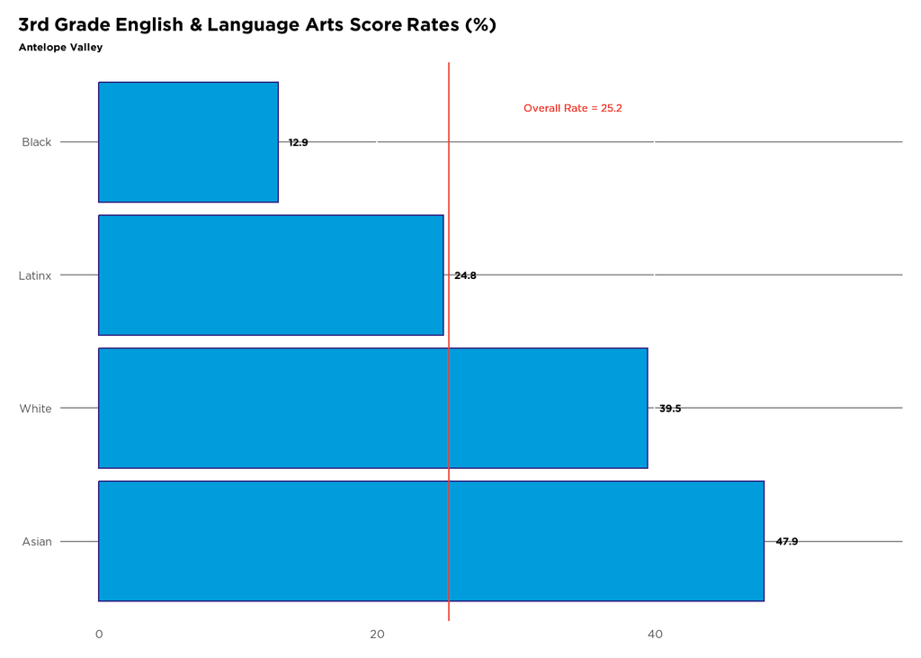

```r
# AV Bar Chart

s <- AV
tot = subset(s, select=c(Total)) # pull out Total
s = subset(s, select=-c(Total)) # pull out raced rates


# create english / spanish labels
engvar = c("Black", "Filipinx", "Latinx", "White", "Two or more", "Asian")
esvar = c("Negro", "Filipino", "Latino", "Blanco", "Dos o mas", "Asiático")

labels <- data.frame(engvar, esvar)
# labels


# convert df to long format
s_long <- reshape2::melt(s, id.vars=c("geoname"))
# Round 'value' field to 1 decimal, rename 'variable' field, add Spanish labels
s_long <- s_long %>% mutate(value = round(value, 1)) %>% dplyr::rename(engvar = variable)  %>%
  left_join(labels, by = "engvar")
s_long <- s_long %>% filter(value > 0)


df <- data.frame(s_long, tot)       # add Total to long table
df <- na.omit(df)             # drop NA's
# df

engtot_stat <- paste("Overall Rate =", min(df$Total))   # Total line annotation
estot_stat <- paste("Promedio Total =", min(df$Total))   # Total line annotation


# Set region name for file name
region <- "Antelope Valley"


# write the name of your indicator here:
var <- "3rd_grade_ela"


# Define chart height as max y value varies by indicator. Set vertical position for total line label - may need to be customized for each chart.
max_y = 1.15 * max(df$value)
annotate_y = 1.12 * (df$Total)

# specify language: comment out based on language of chart created below
lang <- "eng"


# # ggplot method that should export as .svg ##
av_plot <-
  #English
  ggplot(df, aes(x= reorder(engvar, -value), y=value)) +     # set up manual fill using 'test', add "-" before value to order bars when MAX is best
  annotate("text", x=4.25, y = annotate_y, label = str_wrap(engtot_stat, width = 20), hjust=-0.33, vjust = 0.35, family= font_table_text, color = red) +
  labs(title = "**<span style='font-size:20pt;'>3rd Grade English & Language Arts Score Rates (%)</span>**", subtitle = region) +
  # rest of chart
  geom_bar(stat="identity", position = position_dodge(0.7), show.legend = FALSE) +
  geom_col(fill = lightblue, color = darkblue) +         # all bars in "#355C7D"
  geom_hline(aes(yintercept = round(Total, 1)), color = red, size = .5) +
  geom_text(aes(label = round(value, digits = 1)), family = font_bar_label, hjust = -.5) +       # format data labels, adjust hjust to avoid overlap w/ total line
  # scale_y_continuous(limits = c(0, max_y), breaks = seq(0, max_y, by = 20)) +
  scale_x_discrete(labels = function(engvar) str_wrap(engvar, width = 20)) +            # wrap long labels
  xlab("") +
  ylab("") +
  coord_flip()
# av_plot

av_plot <- av_plot + theme(
  panel.background = element_rect(fill = "transparent"), # bg of the panel
  plot.background = element_rect(fill = 'transparent', color=NA),
  panel.grid.major.y = element_line(colour = textgrey),    # add major y-axis gridlines
  panel.grid.minor = element_blank(), # bg of the plot
  axis.title.x = element_blank(),
  axis.title.y = element_blank(),
  axis.text.x = element_text(size = 12, family= font_axis_label),
  axis.text.y = element_text(size = 12, family= font_axis_label),
  axis.ticks = element_blank(),
  plot.title = element_markdown(family = font_title, face = "bold", size = 15, hjust = 0),
  plot.title.position = "plot",
  plot.subtitle = element_text(family = font_title, hjust = 0),
  plot.margin = margin(t = 10,
                       b = 10,
                       r = 10,
                       l = 10)
)


av_plot <- av_plot + ylim(0, max_y)     # add buffer between title and chart/data labels
av_plot
```

# Safety and Justice

## Police Violence

In Antelope Valley ZIP codes, law enforcement visits the most violence on Black residents per 100,000 people.

```r
source("W:/Project/RDA Team/Region 5 State of the Child/R/use_of_force.R")

library(kableExtra)
kbl(police_violence_data) %>%
  kable_styling(bootstrap_options = c("striped", "bordered", "condensed"))
```

| race_ethnicity | pop | number | per_100k |
| --- | --- | --- | --- |
| Black | 63449 | 12 | 3.152138 |
| White | 107748 | 16 | 2.474911 |
| Total | 386337 | 53 | 2.286432 |
| Latinx | 195728 | 25 | 2.128805 |
| AIAN | 8898 | 0 | 0.000000 |
| API | 22077 | 0 | 0.000000 |

## Traffic Stops

Black and NHPI populations are significantly more likely to be stopped by the Sheriff’s Police Department than the race groups. For example, Blacks are 2.4 times more likely to be stopped than Whites and NHPIs are 2.5 times more likely to be stopped than Whites. While there is not a data set available that can be clipped for the just the Antelope Valley region, we do see that within the police jurisdiction that covers this region, there is a racial discrepancy in stop rates.

```r
library(RPostgreSQL)
# con <- dbConnect(drv, dbname = "region5stateofthechild",
#                    host = "aws-postgres-db.c5udgz7ro8hq.us-west-2.rds.amazonaws.com", port = 5432,
#                    user = "postgres", password = pw)

source("W:\\RDA Team\\R\\credentials_source.R")
con <- connect_to_db("region5stateofthechild")

df <- dbGetQuery(con, "SELECT * FROM lasd_stop_rate_by_race_2020")



df_stop_rate<-df%>%
  gather(measure_rate, value_rate, asian:twoormor_rate, factor_key = TRUE)%>%
  filter(grepl('_rate', measure_rate)) %>% #filtering for rates only
  mutate(race_label = ifelse(measure_rate %in% 'total_rate', "Total",
                             ifelse(measure_rate %in% 'latinx_rate', "Latinx",
                                    ifelse(measure_rate %in% 'black_rate', "Black",
                                           ifelse(measure_rate %in% 'asian_rate',"Asian",
                                                  ifelse(measure_rate %in% 'aian_rate', "American Indian/Alaska Native",
                                                         ifelse(measure_rate %in% 'white_rate', "White",
                                                                ifelse(measure_rate %in% 'nhopi_rate', "Native Hawaiian/Pacific Islander",
                                                                       ifelse(measure_rate %in% 'twoormor_rate', "Two or More", "Blank")))))))))

df_stop_rate$value_rate <- as.numeric(df_stop_rate$value_rate)

#convert to long for estimates only

df_stop_est<-df%>%
  select(1:12)%>%
  gather(measure_est, value_est, asian:all_races, factor_key = TRUE)%>%
  filter(!grepl('_rate', measure_est)) %>% #filtering for rates only
  mutate(race_label = ifelse(measure_est %in% 'all_races', "Total",
                             ifelse(measure_est %in% 'hispanic', "Latinx",
                                    ifelse(measure_est %in% 'black', "Black",
                                           ifelse(measure_est %in% 'asian',"Asian",
                                                  ifelse(measure_est %in% 'native_american', "American Indian/Alaska Native",
                                                         ifelse(measure_est %in% 'white', "White",
                                                                ifelse(measure_est %in% 'pacific_islander', "Native Hawaiian/Pacific Islander",
                                                                       ifelse(measure_est %in% 'multiracial', "Two or More", "Blank")))))))))%>%
  filter(!grepl('Blank', race_label))

#change order of rows to match rates table

df_stop_est<-df_stop_est[c(8,3,2,1,5,7,6,4),]



#now recombine

stop_data<-cbind(df_stop_rate, df_stop_est)%>%
  select(1:5,10:12)

stop_data <- stop_data[c(8, 7, 5)] %>% rename(Race = race_label,
                                              Stops_Estimated = value_est,
                                              Stops_Rate = value_rate)

library(kableExtra)
kbl(stop_data) %>%
  kable_styling(bootstrap_options = c("striped", "bordered", "condensed"))
```

|  | Race | Stops_Estimated | Stops_Rate |
| --- | --- | --- | --- |
| 8 | Total | 104275 | 10.4 |
| 3 | Latinx | 50788 | 10.5 |
| 2 | Black | 17916 | 23.0 |
| 1 | Asian | 6256 | 4.3 |
| 5 | American Indian/Alaska Native | 51 | 2.6 |
| 7 | White | 24952 | 9.6 |
| 6 | Native Hawaiian/Pacific Islander | 526 | 23.9 |
| 4 | Two or More | 1486 | 2.0 |

Source: [Open Justice CA DOJ Portal, 2020](https://openjustice.doj.ca.gov/data)  
[American Community Survey Table DP05, 2020](https://data.census.gov/table?tid=ACSDP5Y2020.DP05)

## Hate Crimes

Between 2003 and 2020, 385 hate crimes were reported in the Antelope Valley, SPA 1, for a rate of 97 hate crimes per 100,000 people. Antelope Valley residents were subject to more hate crimes per capita than LA County residents, as LA County’s hate crime rate was 67 hate crimes per 100,000 people during the same time period. Hate crimes against racial-ethnic groups made up 71% of AV hate crimes with 169 hate crimes perpetrated against Black AV residents, 61 hate crimes perpetrated against Latinx residents, and 45 hate crimes perpetrated against others.

```r
source("W:/Project/RDA Team/Region 5 State of the Child/R/hate_crimes.R")

library(kableExtra)
kbl(hate_crime_table) %>%
  kable_styling(bootstrap_options = c("striped", "bordered", "condensed"))
```

|  | AV Hate Crimes 2003-2020 | AV Hate Crimes per 100k | LA County Hate Crimes per 100k |
| --- | --- | --- | --- |
| Disability | 1 | 0.01 | 0.01 |
| Race-ethnicity | 275 | 3.77 | 2.13 |
| Religion | 41 | 0.56 | 0.67 |
| Sexual Orientation | 54 | 0.74 | 0.74 |
| Unknown | 10 | 0.14 | 0.10 |
| TOTAL | 385 | 5.28 | 3.81 |

Source: Catalyst California calculations of [Los Angeles County Human Resources Commission 2003-2020](https://egis-lacounty.hub.arcgis.com/datasets/lacounty::reported-hate-crimes/explore?location=34.215272%2C-118.173107%2C7.95) hate crimes and 2020 American Community Survey 5-year population estimates. Rates of hate crimes presented are the average number of hate crimes in the time period per 100,000 people. Antelope Valley in this table is the aggregation of census tracts in SPA 1.